# Group4_Phase_4_HCDR

#### **Stacking**

```python
from sklearn.ensemble import StackingClassifier

meta_model = Pipeline([
    ('LogisticRegression', LogisticRegression(random_state=42))
])

stacking_models = {
    "DecisionTree": DecisionTreeClassifier(random_state=42),
    "RandomForest": RandomForestClassifier(random_state=42),
}
```

```python
stacking_preprocessor = ColumnTransformer(
    transformers=[
        ('num', numerical_transformer, numerical_features),
        ('cat', categorical_transformer, categorical_features)
    ]
)
```

```python
stacking_estimators = [
    (name, Pipeline([
        ('preprocessor', stacking_preprocessor),
        ('model', pipeline)
    ]))
    for name, pipeline in stacking_models.items()
]
stacking_clf = StackingClassifier(
    estimators=stacking_estimators,
    final_estimator=meta_model
)
```

```python
%%time
stacking_clf.fit(X_train_reduced, y_train)
```

```
CPU times: user 11min 57s, sys: 1.87 s, total: 11min 59s
Wall time: 11min 55s
```

```
StackingClassifier(estimators=[('DecisionTree',
                                Pipeline(steps=[('preprocessor',
                                                 ColumnTransformer(transformers=[('num',
                                                                                  Pipeline(steps=[('imputer',
                                                                                                   SimpleImputer()),
                                                                                                  ('scaler',
                                                                                                   StandardScaler())]),
                                                                                  ['num__DAYS_LAST_PHONE_CHANGE',
                                                                                   'num__DAYS_BIRTH',
                                                                                   'num__SK_ID_CURR',
                                                                                   'num__EXT_SOURCE_2',
                                                                                   'num__POS_MONTHS_BALANCE_MEAN',
                                                                                   'num__REGION_POPULATION_RELATIVE',
                                                                                   'num__...
                                                                                   'num__payment_delay_days_mean',
                                                                                   'num__EXT_SOURCE_1',
                                                                                   'num__AMT_ANNUITY',
                                                                                   'num__DAYS_EMPLOYED',
                                                                                   'num__EXT_SOURCE_3',
                                                                                   'num__AMT_APPLICATION_mean']),
                                                                                 ('cat',
                                                                                  Pipeline(steps=[('target_encoder',
                                                                                                   TargetEncoder(handle_unknown='ignore'))]),
                                                                                  [])])),
                                                ('model',
                                                 RandomForestClassifier(random_state=42))]))],
                   final_estimator=Pipeline(steps=[('LogisticRegression',
                                                    LogisticRegression(random_state=42))]))
```

```python
y_pred_stacking = stacking_clf.predict(X_test_reduced)
```

```python
print("\nStacking Classifier Performance:")
print(f"Accuracy: {accuracy_score(y_test, y_pred_stacking):.4f}")
print(classification_report(y_test, y_pred_stacking))
```

```
Stacking Classifier Performance:
Accuracy: 0.9156
              precision    recall  f1-score   support

           0       0.92      1.00      0.96     35915
           1       0.45      0.02      0.04      3293

    accuracy                           0.92     39208
   macro avg       0.68      0.51      0.50     39208
weighted avg       0.88      0.92      0.88     39208
```

```python
populate_expLog(X_train_reduced, X_valid_reduced, X_test_reduced, "Stacking_ensemble",stacking_clf)
```

```python
expLog
```

|  | Experiment_Name | Train_Accuracy | Valid_Accuracy | Test_Accuracy | Train_ROC_AUC | Valid_ROC_AUC | Test_ROC_AUC | Train_Precision | Valid_Precision | Test_Precision | Train_Recall | Valid_Recall | Test_Recall | Train_F1 | Valid_F1 | Test_F1 | Train_Log_Loss | Valid_Log_Loss | Test_Log_Loss |
| --- | --- | --- | --- | --- | --- | --- | --- | --- | --- | --- | --- | --- | --- | --- | --- | --- | --- | --- | --- |
| 0 | LogisticRegression_208_features | 0.9197 | 0.9197 | 0.9160 | 0.7608 | 0.7537 | 0.7594 | 0.4870 | 0.5448 | 0.4955 | 0.0179 | 0.0196 | 0.0167 | 0.0345 | 0.0379 | 0.0323 | 0.2451 | 0.2478 | 0.2540 |
| 1 | DecisionTree_208_features | 1.0000 | 0.8546 | 0.8499 | 1.0000 | 0.5443 | 0.5416 | 1.0000 | 0.1511 | 0.1515 | 1.0000 | 0.1743 | 0.1710 | 1.0000 | 0.1619 | 0.1606 | 0.0000 | 5.2424 | 5.4091 |
| 2 | RandomForest_208_features | 1.0000 | 0.9195 | 0.9162 | 1.0000 | 0.7212 | 0.7237 | 1.0000 | 0.7500 | 0.9000 | 0.9998 | 0.0024 | 0.0027 | 0.9999 | 0.0048 | 0.0054 | 0.0600 | 0.2772 | 0.2828 |
| 3 | GradientBoosting_208_features | 0.9208 | 0.9198 | 0.9162 | 0.7784 | 0.7656 | 0.7678 | 0.6870 | 0.5645 | 0.5357 | 0.0228 | 0.0188 | 0.0182 | 0.0441 | 0.0364 | 0.0352 | 0.2394 | 0.2437 | 0.2518 |
| 4 | XGBoosting_208_features | 0.9291 | 0.9192 | 0.9149 | 0.8847 | 0.7647 | 0.7688 | 0.8561 | 0.4910 | 0.4357 | 0.1395 | 0.0584 | 0.0452 | 0.2400 | 0.1044 | 0.0820 | 0.1940 | 0.2448 | 0.2523 |
| 5 | LightGradientBoosting_208_features | 0.9225 | 0.9204 | 0.9165 | 0.8249 | 0.7743 | 0.7739 | 0.7655 | 0.5966 | 0.5538 | 0.0491 | 0.0374 | 0.0313 | 0.0923 | 0.0704 | 0.0592 | 0.2229 | 0.2404 | 0.2491 |
| 6 | LightGradientBoosting_208_features | 0.9340 | 0.9199 | 0.9163 | 0.9994 | 0.7538 | 0.7554 | 1.0000 | 0.5660 | 0.5385 | 0.1765 | 0.0242 | 0.0234 | 0.3000 | 0.0464 | 0.0448 | 0.1231 | 0.2491 | 0.2571 |
| 7 | LightGradientBoosting_208_features | 1.0000 | 0.9198 | 0.9161 | 1.0000 | 0.7213 | 0.7235 | 1.0000 | 0.5450 | 0.5177 | 1.0000 | 0.0293 | 0.0222 | 1.0000 | 0.0557 | 0.0425 | 0.0426 | 0.2544 | 0.2626 |
| 8 | LogisticRegression_20_features | 0.9197 | 0.9193 | 0.9160 | 0.7266 | 0.7263 | 0.7257 | 0.4467 | 0.4375 | 0.4737 | 0.0049 | 0.0038 | 0.0055 | 0.0098 | 0.0075 | 0.0108 | 0.2540 | 0.2553 | 0.2626 |
| 9 | DecisionTree_20_features | 1.0000 | 0.8553 | 0.8489 | 1.0000 | 0.5401 | 0.5344 | 1.0000 | 0.1462 | 0.1407 | 1.0000 | 0.1644 | 0.1564 | 1.0000 | 0.1548 | 0.1481 | 0.0000 | 5.2151 | 5.4450 |
| 10 | RandomForest_20_features | 1.0000 | 0.9196 | 0.9162 | 1.0000 | 0.7189 | 0.7107 | 1.0000 | 0.6389 | 0.6250 | 0.9994 | 0.0062 | 0.0046 | 0.9997 | 0.0123 | 0.0090 | 0.0599 | 0.2777 | 0.2977 |
| 11 | GradientBoosting_20_features | 0.9204 | 0.9196 | 0.9160 | 0.7552 | 0.7450 | 0.7474 | 0.6704 | 0.5455 | 0.4833 | 0.0136 | 0.0113 | 0.0088 | 0.0266 | 0.0221 | 0.0173 | 0.2462 | 0.2495 | 0.2574 |
| 12 | XGBoosting_20_features | 0.9256 | 0.9189 | 0.9151 | 0.8621 | 0.7421 | 0.7394 | 0.8825 | 0.4552 | 0.4167 | 0.0831 | 0.0328 | 0.0273 | 0.1519 | 0.0612 | 0.0513 | 0.2076 | 0.2517 | 0.2608 |
| 13 | LightGradientBoosting_20_features | 0.9209 | 0.9194 | 0.9159 | 0.7957 | 0.7483 | 0.7498 | 0.7905 | 0.4835 | 0.4667 | 0.0186 | 0.0118 | 0.0085 | 0.0364 | 0.0231 | 0.0167 | 0.2340 | 0.2483 | 0.2565 |
| 14 | LightGradientBoosting_20_features | 0.9293 | 0.9195 | 0.9156 | 0.9996 | 0.7330 | 0.7305 | 1.0000 | 0.5207 | 0.4096 | 0.1184 | 0.0169 | 0.0103 | 0.2117 | 0.0328 | 0.0201 | 0.1274 | 0.2554 | 0.2648 |
| 15 | LightGradientBoosting_20_features | 1.0000 | 0.9191 | 0.9156 | 1.0000 | 0.7190 | 0.7108 | 1.0000 | 0.4667 | 0.4476 | 1.0000 | 0.0245 | 0.0194 | 1.0000 | 0.0465 | 0.0373 | 0.0517 | 0.2563 | 0.2661 |

```python
# Create a copy of the DataFrame as a backup
expLog1 = expLog.copy()

# save expLog
expLog1.to_csv('expLog_phase4.csv', index=False)

# Renaming the specific experiments for clarity on the LightGradientBoosting based on just the LightGBM versus the ensemble models. #TODO: Name these experiments appropriately in run time
expLog.loc[6, 'Experiment_Name'] = 'LightGradientBoosting_208_features_Voting_ensemble'
expLog.loc[7, 'Experiment_Name'] = 'LightGradientBoosting_208_features_Stacking_ensemble'
expLog.loc[14, 'Experiment_Name'] = 'LightGradientBoosting_20_features_Voting_ensemble'
expLog.loc[15, 'Experiment_Name'] = 'LightGradientBoosting_20_features_Stacking_ensemble'

# Verify the changes
expLog
```

|  | Experiment_Name | Train_Accuracy | Valid_Accuracy | Test_Accuracy | Train_ROC_AUC | Valid_ROC_AUC | Test_ROC_AUC | Train_Precision | Valid_Precision | Test_Precision | Train_Recall | Valid_Recall | Test_Recall | Train_F1 | Valid_F1 | Test_F1 | Train_Log_Loss | Valid_Log_Loss | Test_Log_Loss |
| --- | --- | --- | --- | --- | --- | --- | --- | --- | --- | --- | --- | --- | --- | --- | --- | --- | --- | --- | --- |
| 0 | LogisticRegression_208_features | 0.9197 | 0.9197 | 0.9160 | 0.7608 | 0.7537 | 0.7594 | 0.4870 | 0.5448 | 0.4955 | 0.0179 | 0.0196 | 0.0167 | 0.0345 | 0.0379 | 0.0323 | 0.2451 | 0.2478 | 0.2540 |
| 1 | DecisionTree_208_features | 1.0000 | 0.8546 | 0.8499 | 1.0000 | 0.5443 | 0.5416 | 1.0000 | 0.1511 | 0.1515 | 1.0000 | 0.1743 | 0.1710 | 1.0000 | 0.1619 | 0.1606 | 0.0000 | 5.2424 | 5.4091 |
| 2 | RandomForest_208_features | 1.0000 | 0.9195 | 0.9162 | 1.0000 | 0.7212 | 0.7237 | 1.0000 | 0.7500 | 0.9000 | 0.9998 | 0.0024 | 0.0027 | 0.9999 | 0.0048 | 0.0054 | 0.0600 | 0.2772 | 0.2828 |
| 3 | GradientBoosting_208_features | 0.9208 | 0.9198 | 0.9162 | 0.7784 | 0.7656 | 0.7678 | 0.6870 | 0.5645 | 0.5357 | 0.0228 | 0.0188 | 0.0182 | 0.0441 | 0.0364 | 0.0352 | 0.2394 | 0.2437 | 0.2518 |
| 4 | XGBoosting_208_features | 0.9291 | 0.9192 | 0.9149 | 0.8847 | 0.7647 | 0.7688 | 0.8561 | 0.4910 | 0.4357 | 0.1395 | 0.0584 | 0.0452 | 0.2400 | 0.1044 | 0.0820 | 0.1940 | 0.2448 | 0.2523 |
| 5 | LightGradientBoosting_208_features | 0.9225 | 0.9204 | 0.9165 | 0.8249 | 0.7743 | 0.7739 | 0.7655 | 0.5966 | 0.5538 | 0.0491 | 0.0374 | 0.0313 | 0.0923 | 0.0704 | 0.0592 | 0.2229 | 0.2404 | 0.2491 |
| 6 | LightGradientBoosting_208_features_Voting_ense... | 0.9340 | 0.9199 | 0.9163 | 0.9994 | 0.7538 | 0.7554 | 1.0000 | 0.5660 | 0.5385 | 0.1765 | 0.0242 | 0.0234 | 0.3000 | 0.0464 | 0.0448 | 0.1231 | 0.2491 | 0.2571 |
| 7 | LightGradientBoosting_208_features_Stacking_en... | 1.0000 | 0.9198 | 0.9161 | 1.0000 | 0.7213 | 0.7235 | 1.0000 | 0.5450 | 0.5177 | 1.0000 | 0.0293 | 0.0222 | 1.0000 | 0.0557 | 0.0425 | 0.0426 | 0.2544 | 0.2626 |
| 8 | LogisticRegression_20_features | 0.9197 | 0.9193 | 0.9160 | 0.7266 | 0.7263 | 0.7257 | 0.4467 | 0.4375 | 0.4737 | 0.0049 | 0.0038 | 0.0055 | 0.0098 | 0.0075 | 0.0108 | 0.2540 | 0.2553 | 0.2626 |
| 9 | DecisionTree_20_features | 1.0000 | 0.8553 | 0.8489 | 1.0000 | 0.5401 | 0.5344 | 1.0000 | 0.1462 | 0.1407 | 1.0000 | 0.1644 | 0.1564 | 1.0000 | 0.1548 | 0.1481 | 0.0000 | 5.2151 | 5.4450 |
| 10 | RandomForest_20_features | 1.0000 | 0.9196 | 0.9162 | 1.0000 | 0.7189 | 0.7107 | 1.0000 | 0.6389 | 0.6250 | 0.9994 | 0.0062 | 0.0046 | 0.9997 | 0.0123 | 0.0090 | 0.0599 | 0.2777 | 0.2977 |
| 11 | GradientBoosting_20_features | 0.9204 | 0.9196 | 0.9160 | 0.7552 | 0.7450 | 0.7474 | 0.6704 | 0.5455 | 0.4833 | 0.0136 | 0.0113 | 0.0088 | 0.0266 | 0.0221 | 0.0173 | 0.2462 | 0.2495 | 0.2574 |
| 12 | XGBoosting_20_features | 0.9256 | 0.9189 | 0.9151 | 0.8621 | 0.7421 | 0.7394 | 0.8825 | 0.4552 | 0.4167 | 0.0831 | 0.0328 | 0.0273 | 0.1519 | 0.0612 | 0.0513 | 0.2076 | 0.2517 | 0.2608 |
| 13 | LightGradientBoosting_20_features | 0.9209 | 0.9194 | 0.9159 | 0.7957 | 0.7483 | 0.7498 | 0.7905 | 0.4835 | 0.4667 | 0.0186 | 0.0118 | 0.0085 | 0.0364 | 0.0231 | 0.0167 | 0.2340 | 0.2483 | 0.2565 |
| 14 | LightGradientBoosting_20_features_Voting_ensemble | 0.9293 | 0.9195 | 0.9156 | 0.9996 | 0.7330 | 0.7305 | 1.0000 | 0.5207 | 0.4096 | 0.1184 | 0.0169 | 0.0103 | 0.2117 | 0.0328 | 0.0201 | 0.1274 | 0.2554 | 0.2648 |
| 15 | LightGradientBoosting_20_features_Stacking_ens... | 1.0000 | 0.9191 | 0.9156 | 1.0000 | 0.7190 | 0.7108 | 1.0000 | 0.4667 | 0.4476 | 1.0000 | 0.0245 | 0.0194 | 1.0000 | 0.0465 | 0.0373 | 0.0517 | 0.2563 | 0.2661 |

### **3.4.10 SVC model with PCA features using 20% of the training data**

We added in Support Vector Machines Classifier since it requires few resources given our reduced feature set and we used 20% of the training data to see the extent to which it was worth it to run it on the full training data. However, the results of the reduced SVC did not lead to signficant gains in performance.

```python
## Reduced training dataset to 20% of its prior size
X_train_reduced_SVC, X_unused, y_train_reduced_SVC, y_unused = train_test_split(X_train_reduced, y_train, test_size=0.8, random_state=42)
```

```python
X_train_reduced_SVC = X_train_reduced_SVC.reset_index(drop=True)
y_train_reduced_SVC = y_train_reduced_SVC.reset_index(drop=True)
```

```python
reduced_SVC_pipeline = Pipeline([
    ('target_encoder', TargetEncoder(handle_unknown='ignore')),
    ('imputer', SimpleImputer(strategy='mean')),
    ('SVC', SVC(random_state=42, probability=True))
])
```

```python
%%time
reduced_SVC_pipeline.fit(X_train_reduced_SVC, y_train_reduced_SVC)
```

```
Pipeline(steps=[('target_encoder',
                 TargetEncoder(cols=[], handle_unknown='ignore')),
                ('imputer', SimpleImputer()),
                ('SVC', SVC(probability=True, random_state=42))])
```

```python
y_pred_reduced_SVC = reduced_SVC_pipeline.predict(X_test_reduced)
```

```python
print("\nSVC with 20% of training data Performance:")
print(f"Accuracy: {accuracy_score(y_test, y_pred_reduced_SVC):.4f}")
print(classification_report(y_test, y_pred_reduced_SVC))
```

```
SVC with 20% of training data Performance:
Accuracy: 0.9160
              precision    recall  f1-score   support

           0       0.92      1.00      0.96     35915
           1       0.00      0.00      0.00      3293

    accuracy                           0.92     39208
   macro avg       0.46      0.50      0.48     39208
weighted avg       0.84      0.92      0.88     39208
```

```python
exp_name = f"SVC_20%_{X_train_reduced_SVC.shape[1]}_features"
expLog.loc[len(expLog)] = [f"{exp_name}"] + list(np.round(
               [accuracy_score(y_train_reduced_SVC, reduced_SVC_pipeline.predict(X_train_reduced_SVC)),
                accuracy_score(y_valid, reduced_SVC_pipeline.predict(X_valid_reduced)),
                accuracy_score(y_test, reduced_SVC_pipeline.predict(X_test_reduced)),
                roc_auc_score(y_train_reduced_SVC, reduced_SVC_pipeline.predict_proba(X_train_reduced_SVC)[:, 1]),
                roc_auc_score(y_valid, reduced_SVC_pipeline.predict_proba(X_valid_reduced)[:, 1]),
                roc_auc_score(y_test, reduced_SVC_pipeline.predict_proba(X_test_reduced)[:, 1]),
                precision_score(y_train_reduced_SVC, reduced_SVC_pipeline.predict(X_train_reduced_SVC)),
                precision_score(y_valid, reduced_SVC_pipeline.predict(X_valid_reduced)),
                precision_score(y_test, reduced_SVC_pipeline.predict(X_test_reduced)),
                recall_score(y_train_reduced_SVC, reduced_SVC_pipeline.predict(X_train_reduced_SVC)),
                recall_score(y_valid, reduced_SVC_pipeline.predict(X_valid_reduced)),
                recall_score(y_test, reduced_SVC_pipeline.predict(X_test_reduced)),
                f1_score(y_train_reduced_SVC, reduced_SVC_pipeline.predict(X_train_reduced_SVC)),
                f1_score(y_valid, reduced_SVC_pipeline.predict(X_valid_reduced)),
                f1_score(y_test, reduced_SVC_pipeline.predict(X_test_reduced)),
                log_loss(y_train_reduced_SVC, reduced_SVC_pipeline.predict_proba(X_train_reduced_SVC)[:, 1]),
                log_loss(y_valid, reduced_SVC_pipeline.predict_proba(X_valid_reduced)[:, 1]),
                log_loss(y_test, reduced_SVC_pipeline.predict_proba(X_test_reduced)[:, 1])],

    4))
expLog
```

|  | Experiment_Name | Train_Accuracy | Valid_Accuracy | Test_Accuracy | Train_ROC_AUC | Valid_ROC_AUC | Test_ROC_AUC | Train_Precision | Valid_Precision | Test_Precision | Train_Recall | Valid_Recall | Test_Recall | Train_F1 | Valid_F1 | Test_F1 | Train_Log_Loss | Valid_Log_Loss | Test_Log_Loss |
| --- | --- | --- | --- | --- | --- | --- | --- | --- | --- | --- | --- | --- | --- | --- | --- | --- | --- | --- | --- |
| 0 | LogisticRegression_208_features | 0.9197 | 0.9197 | 0.9160 | 0.7608 | 0.7537 | 0.7594 | 0.4870 | 0.5448 | 0.4955 | 0.0179 | 0.0196 | 0.0167 | 0.0345 | 0.0379 | 0.0323 | 0.2451 | 0.2478 | 0.2540 |
| 1 | DecisionTree_208_features | 1.0000 | 0.8546 | 0.8499 | 1.0000 | 0.5443 | 0.5416 | 1.0000 | 0.1511 | 0.1515 | 1.0000 | 0.1743 | 0.1710 | 1.0000 | 0.1619 | 0.1606 | 0.0000 | 5.2424 | 5.4091 |
| 2 | RandomForest_208_features | 1.0000 | 0.9195 | 0.9162 | 1.0000 | 0.7212 | 0.7237 | 1.0000 | 0.7500 | 0.9000 | 0.9998 | 0.0024 | 0.0027 | 0.9999 | 0.0048 | 0.0054 | 0.0600 | 0.2772 | 0.2828 |
| 3 | GradientBoosting_208_features | 0.9208 | 0.9198 | 0.9162 | 0.7784 | 0.7656 | 0.7678 | 0.6870 | 0.5645 | 0.5357 | 0.0228 | 0.0188 | 0.0182 | 0.0441 | 0.0364 | 0.0352 | 0.2394 | 0.2437 | 0.2518 |
| 4 | XGBoosting_208_features | 0.9291 | 0.9192 | 0.9149 | 0.8847 | 0.7647 | 0.7688 | 0.8561 | 0.4910 | 0.4357 | 0.1395 | 0.0584 | 0.0452 | 0.2400 | 0.1044 | 0.0820 | 0.1940 | 0.2448 | 0.2523 |
| 5 | LightGradientBoosting_208_features | 0.9225 | 0.9204 | 0.9165 | 0.8249 | 0.7743 | 0.7739 | 0.7655 | 0.5966 | 0.5538 | 0.0491 | 0.0374 | 0.0313 | 0.0923 | 0.0704 | 0.0592 | 0.2229 | 0.2404 | 0.2491 |
| 6 | LightGradientBoosting_208_features_Voting_ense... | 0.9340 | 0.9199 | 0.9163 | 0.9994 | 0.7538 | 0.7554 | 1.0000 | 0.5660 | 0.5385 | 0.1765 | 0.0242 | 0.0234 | 0.3000 | 0.0464 | 0.0448 | 0.1231 | 0.2491 | 0.2571 |
| 7 | LightGradientBoosting_208_features_Stacking_en... | 1.0000 | 0.9198 | 0.9161 | 1.0000 | 0.7213 | 0.7235 | 1.0000 | 0.5450 | 0.5177 | 1.0000 | 0.0293 | 0.0222 | 1.0000 | 0.0557 | 0.0425 | 0.0426 | 0.2544 | 0.2626 |
| 8 | LogisticRegression_20_features | 0.9197 | 0.9193 | 0.9160 | 0.7266 | 0.7263 | 0.7257 | 0.4467 | 0.4375 | 0.4737 | 0.0049 | 0.0038 | 0.0055 | 0.0098 | 0.0075 | 0.0108 | 0.2540 | 0.2553 | 0.2626 |
| 9 | DecisionTree_20_features | 1.0000 | 0.8553 | 0.8489 | 1.0000 | 0.5401 | 0.5344 | 1.0000 | 0.1462 | 0.1407 | 1.0000 | 0.1644 | 0.1564 | 1.0000 | 0.1548 | 0.1481 | 0.0000 | 5.2151 | 5.4450 |
| 10 | RandomForest_20_features | 1.0000 | 0.9196 | 0.9162 | 1.0000 | 0.7189 | 0.7107 | 1.0000 | 0.6389 | 0.6250 | 0.9994 | 0.0062 | 0.0046 | 0.9997 | 0.0123 | 0.0090 | 0.0599 | 0.2777 | 0.2977 |
| 11 | GradientBoosting_20_features | 0.9204 | 0.9196 | 0.9160 | 0.7552 | 0.7450 | 0.7474 | 0.6704 | 0.5455 | 0.4833 | 0.0136 | 0.0113 | 0.0088 | 0.0266 | 0.0221 | 0.0173 | 0.2462 | 0.2495 | 0.2574 |
| 12 | XGBoosting_20_features | 0.9256 | 0.9189 | 0.9151 | 0.8621 | 0.7421 | 0.7394 | 0.8825 | 0.4552 | 0.4167 | 0.0831 | 0.0328 | 0.0273 | 0.1519 | 0.0612 | 0.0513 | 0.2076 | 0.2517 | 0.2608 |
| 13 | LightGradientBoosting_20_features | 0.9209 | 0.9194 | 0.9159 | 0.7957 | 0.7483 | 0.7498 | 0.7905 | 0.4835 | 0.4667 | 0.0186 | 0.0118 | 0.0085 | 0.0364 | 0.0231 | 0.0167 | 0.2340 | 0.2483 | 0.2565 |
| 14 | LightGradientBoosting_20_features_Voting_ensemble | 0.9293 | 0.9195 | 0.9156 | 0.9996 | 0.7330 | 0.7305 | 1.0000 | 0.5207 | 0.4096 | 0.1184 | 0.0169 | 0.0103 | 0.2117 | 0.0328 | 0.0201 | 0.1274 | 0.2554 | 0.2648 |
| 15 | LightGradientBoosting_20_features_Stacking_ens... | 1.0000 | 0.9191 | 0.9156 | 1.0000 | 0.7190 | 0.7108 | 1.0000 | 0.4667 | 0.4476 | 1.0000 | 0.0245 | 0.0194 | 1.0000 | 0.0465 | 0.0373 | 0.0517 | 0.2563 | 0.2661 |
| 16 | SVC_20%_20_features | 0.9185 | 0.9194 | 0.9160 | 0.9035 | 0.6113 | 0.6167 | 1.0000 | 0.0000 | 0.0000 | 0.0003 | 0.0000 | 0.0000 | 0.0006 | 0.0000 | 0.0000 | 0.2503 | 0.2765 | 0.2845 |

Below, we give a brief description of the models we tested along with descriptions of common hyperparameters we used for tuning each model.

**Logistic Regression:** Logistic regression (also known as logit regression, maximum-entropy classification (MaxEnt) or the log-linear classifier) is a supervised learning algorithm, implemented as a linear model, used for binary and multiclass classification. It models the probability of a target variable belonging to a class by using a logistic (sigmoid) function. The algorithm works by finding the best-fitting hyperplane that separates the data points of different classes in the feature space. Supported regularization hyperparameters include L1 (Lasso), L2 (Ridge) and Elastic-Net regularization to prevent overfitting and improve generalization.

**[Hyperparameters:](https://scikit-learn.org/dev/modules/linear_model.html)**

- Penalty: Specifies the type of regularization to be applied.
  - Default = "l2"
  - Options = {"l1", "l2", "elasticnet", "none"}
- C: Inverse of regularization strength (smaller values specify stronger regularization).
  - Default = 1.0, Range = (0, inf)
- Solver: Algorithm to be used for optimization.
  - Default = "lbfgs"
  - Options = {"newton-cg", "lbfgs", "liblinear", "sag", "saga"}
- Max_iter: Maximum number of iterations taken for the solvers to converge.
  - Default = 100, Range = [10, inf)
- Multi_class: Handles multiclass classification.
  - Default = "auto"
  - Options = {"auto", "ovr", "multinomial"}

**Support Vector Machines (SVM - Classifier):** Support vector machines (SVMs) are a set of supervised learning methods used for classification, regression and outlier detection. These work by finding the hyperplane that maximizes the margin (distance) between classes in a high-dimensional space. SVMs can handle both linear and non-linear classification tasks by utilizing kernel functions. SVC, NuSVC and LinearSVC are classes capable of performing binary and multi-class classification on a dataset. SVC and NuSVC are similar methods, but accept slightly different sets of parameters and have different mathematical formulations. On the other hand, LinearSVC is another (faster) implementation of Support Vector Classification for the case of a linear kernel. We will use SVC for our work.

**[Hyperparameters:](https://scikit-learn.org/dev/modules/svm.html)**

- C: Regularization parameter that controls the trade-off between maximizing the margin and minimizing classification error.
  - Default = 1.0, Range = (0, inf)
- Kernel: Specifies the kernel type to be used in the algorithm.
  - Default = "rbf"
  - Options = {"linear", "poly", "rbf", "sigmoid", "precomputed"}
- Degree: Degree of the polynomial kernel function (ignored by other kernels).
  - Default = 3, Range = [1, inf)
- Gamma: Defines the influence of a single training example.
  - Default = "scale"
  - Options = {"scale", "auto"} or float
- Class_weight: adjust weights inversely proportional to class frequencies for handling imbalanced datasets.
  - Default = None
  - Options = {None, "balanced", {custom dictionary}}
- Max_iter: Maximum number of iterations in the solver.
  - Default = -1 (no limit)

**Decision Tree Classifier:** Decision trees are supervised learning models used for classification and regression. The tree is structured with a root node (first node with the entire dataset that all other nodes originate from), decision node (node where a choice is made), leaf nodes (final classification). Each node splits the data into subsets based on a feature from the data to lead to a final predictive outcome.

**[Hyperparameters:](https://scikit-learn.org/dev/modules/generated/sklearn.tree.DecisionTreeClassifier.html)**

- Max_depth: maximum depth of the tree.
  - Default = None
- Min_samples_split: minimum number of samples required to split an internal node.
  - Default = 2
- Min_samples_leaf: minimum number of samples required to be at a leaf node.
  - Default = 1

**Random Forest Classifier:** Random forest classifier combines multiple decision tree classifiers on subsets of data. The prediction made from a random forest classifier is based on the classification predicted by most of the individual trees.

**[Hyperparameters:](https://scikit-learn.org/1.5/modules/generated/sklearn.ensemble.RandomForestClassifier.html)**

- N_estimators: Number of trees.
  - Default = 100
- Max_depth: maximum depth of the tree.
  - Default = None
- Min_samples_split: minimum number of samples required to split an internal node.
  - Default = 2
- Min_samples_leaf: minimum number of samples required to be at a leaf node.
  - Default = 1
- Max_features: number of features considered when looking for best split.
  - Default = "sqrt"

**Gradient Boosting (GBM, XGBM, and LightGBM):** Gradient Boosting Machine (GBM) combines weak learning (i.e., models that perform slightly better than chance) decision tree models to create a stronger model. The process is iterative, so later models are built considering mistakes made by earlier models to minimize them. Extreme Gradient Boosting (XGBM) is related to GBM, but XGBM improves upon GBM using parallel processing to increase speed. XGBM also includes regularization hyperparameters that can help with overfitting. Light Gradient Boosting Machine (LightGBM) is another related algorithm that is fast and efficient for large datasets. LightGBM bins data using histograms to use less memory and train faster than GBM.

**Gradient Boosting:**

**[Hyperparameters:](https://scikit-learn.org/dev/modules/generated/sklearn.ensemble.GradientBoostingClassifier.html)**

- Learning_rate: shrinks the contribution of each tree.
  - Default = 0.1
- N_estimators: number of boosting stages to perform. Larger number usually performs better.
  - Default = 100, must be in range [1, inf]
- Max_depth: maximum depth of the individual regression estimators. Limits the number of nodes in the tree. Best value depends on the interaction of the input variables.
  - Default = 3, must be in range [1, inf) or None
- Subsample: fraction of samples to be used for fitting the individual base learners.
  - Default = 1.0, smaller than 1 leads to reduction of variance and increase in bias. Range (0.0, 1.0]
- Min_samples_split: Minimum number of samples required to split an internal node.
  - Default = 2

**Extreme Gradient Boosting:**

**[Hyperparameters:](https://xgboost.readthedocs.io/en/stable/parameter.html)**

- Learning_rate: step size shrinkage used in update to prevent overfitting.
  - Default = 0.3, range [0, 1]
- N_estimators: number of boosting iterations.
  - Default = 100
- Max_depth: maximum depth of a tree. Higher values mean a more complex model that is more likely to overfit.
  - Default = 6, range [0, inf]
- Subsample: subsample ratio of the training instances.
  - Default = 1, range (0, 1]
- Colsample_bytree: subsample ratio of columns when constructing each tree.
  - Default = 1

**Light Gradient Boosting:**

**[Hyperparameters:](https://lightgbm.readthedocs.io/en/latest/Parameters.html)**

- Num_leaves: Parameter to control complexity of model.
  - Default = 31, value should be smaller than 2^(max_depth)
- Learning_rate: Shrinkage rate.
  - Default = 0.1
- N_estimators: Number of boosting iterations.
  - Default = 100
- Min_data_in_leaf: Minimal number of data in one leaf. This parameter can help deal with overfitting.
  - Default = 20
- Max_depth: Limit the max depth for the model.
  - Default = -1 (no limit)

```python
models_PCA_tuning = {
    "XGBoost": {
        "model": XGBClassifier(use_label_encoder=False, eval_metric='logloss', random_state=42),
        "params": {
            "learning_rate": [0.1, 0.2],
            # "n_estimators": [100, 200, 500],
            "max_depth": [3, 5, 7],
            "subsample": [ 0.8, 1.0],
            "colsample_bytree": [0.8, 1.0]
        }
    }
}
```

```python
categorical_features = X_train_reduced.select_dtypes(include=['object', 'category']).columns.tolist()
numerical_features = X_train_reduced.select_dtypes(include=['int64', 'float64']).columns.tolist()

categorical_transformer = Pipeline(steps=[
    ('target_encoder', TargetEncoder(handle_unknown='ignore'))
])

numerical_transformer = Pipeline(steps=[
    ('imputer', SimpleImputer(strategy='mean')),
    ('scaler', StandardScaler())
])

preprocessor = ColumnTransformer(
    transformers=[
        ('num', numerical_transformer, numerical_features),
        ('cat', categorical_transformer, categorical_features)
    ]
)

pipelines = []
for model_name, model_info in models_PCA_tuning.items():
    pipeline = Pipeline(steps=[
        ('preprocessor', preprocessor),
        ('model', model_info['model'])
    ])

    param_grid = {}
    for param_name, param_values in model_info['params'].items():
        param_grid[f"model__{param_name}"] = param_values

    grid_search = GridSearchCV(
        estimator=pipeline,
        param_grid=param_grid,
        cv=3,
        scoring='accuracy',
        n_jobs=-1,
    )

    pipelines.append((model_name, grid_search))
```

```python
best_models_PCA_tuning = {}
for model_name, grid_search in pipelines:
    print(f"Training {model_name}...")
    grid_search.fit(X_train_reduced, y_train)
    best_models_PCA_tuning[model_name] = grid_search.best_estimator_
```

```
Training XGBoost...
```

```python
# Extract best parameters for each model
best_params = []
for model_name, grid_search in pipelines:
    best_params.append({
        'Model': model_name,
        **grid_search.best_params_
    })

# Convert to a DataFrame for visualization
best_params_df = pd.DataFrame(best_params)

# Print the best parameters in a nice format
print("Best Parameters for Each Model:\n")
for index, row in best_params_df.iterrows():
    print(f"Model: {row['Model']}")
    for param, value in row.items():
        if param != 'Model':
            print(f"  {param}: {value}")
    print("-" * 40)  # Separator for readability
```

```
Best Parameters for Each Model:

Model: XGBoost
  model__colsample_bytree: 0.8
  model__learning_rate: 0.1
  model__max_depth: 5
  model__subsample: 1.0
----------------------------------------
```

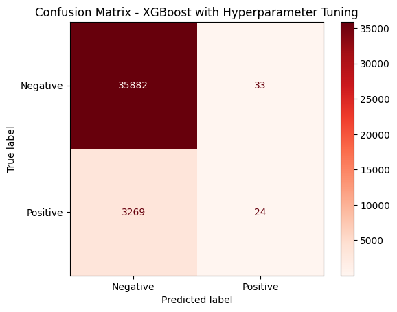

```python
from sklearn.metrics import ConfusionMatrixDisplay

for model_name, model in best_models_PCA_tuning.items():
  y_pred = model.predict(X_test_reduced)
  ConfusionMatrixDisplay.from_predictions(y_test, y_pred, display_labels=["Negative", "Positive"], cmap="Reds")
  plt.title("Confusion Matrix - XGBoost with Hyperparameter Tuning")
  plt.show()
```

```
                         Feature  Importance
3              num__EXT_SOURCE_2    0.238432
18             num__EXT_SOURCE_3    0.213913
15             num__EXT_SOURCE_1    0.063740
1                num__DAYS_BIRTH    0.046522
17            num__DAYS_EMPLOYED    0.041031
4   num__POS_MONTHS_BALANCE_MEAN    0.039695
10   num__payment_delay_days_max    0.039125
16              num__AMT_ANNUITY    0.033453
7         num__AMT_ANNUITY_max_y    0.029998
14  num__payment_delay_days_mean    0.029576
```

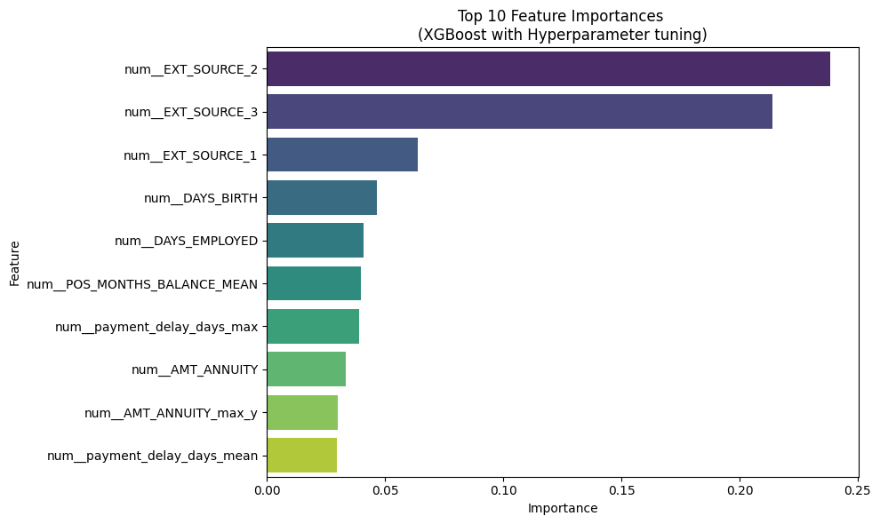

```python
# Get the best XGBoost model
xgboost_model = best_models_PCA_tuning['XGBoost'].named_steps['model']
preprocessor_step = best_models_PCA_tuning['XGBoost'].named_steps['preprocessor']
X_train_transformed = preprocessor_step.fit_transform(X_train_reduced)

# Get the feature importances
feature_importances = xgboost_model.feature_importances_

# Get feature names
final_feature_names = list(X_train_reduced.columns)

# Create a DataFrame for feature importances
importances_df = pd.DataFrame({
    'Feature': final_feature_names,
    'Importance': feature_importances
})

# Sort by importance
importances_df = importances_df.sort_values(by='Importance', ascending=False)

# Display the top features
print(importances_df.head(10))

# Plot feature importances
plt.figure(figsize=(10, 6))
sns.barplot(data=importances_df.head(10), x='Importance', y='Feature', palette='viridis')
plt.title('Top 10 Feature Importances \n(XGBoost with Hyperparameter tuning)')
plt.xlabel('Importance')
plt.ylabel('Feature')
plt.tight_layout()
plt.show()
```

```python
for model_name, model in best_models_PCA_tuning.items():
    y_pred = model.predict(X_test_reduced)
    print(f"\n{model_name} (PCA) Performance:")
    print(f"Accuracy: {accuracy_score(y_test, y_pred):.4f}")
    print(classification_report(y_test, y_pred))
    exp_name = f"XGBoost_hyperparamtune_{X_train_reduced.shape[1]}_features"
    expLog.loc[len(expLog)] = [f"{exp_name}"] + list(np.round(
                  [accuracy_score(y_train, model.predict(X_train_reduced)),
                    accuracy_score(y_valid, model.predict(X_valid_reduced)),
                    accuracy_score(y_test, model.predict(X_test_reduced)),
                    roc_auc_score(y_train, model.predict_proba(X_train_reduced)[:, 1]),
                    roc_auc_score(y_valid, model.predict_proba(X_valid_reduced)[:, 1]),
                    roc_auc_score(y_test, model.predict_proba(X_test_reduced)[:, 1]),
                    precision_score(y_train, model.predict(X_train_reduced)),
                    precision_score(y_valid, model.predict(X_valid_reduced)),
                    precision_score(y_test, model.predict(X_test_reduced)),
                    recall_score(y_train, model.predict(X_train_reduced)),
                    recall_score(y_valid, model.predict(X_valid_reduced)),
                    recall_score(y_test, model.predict(X_test_reduced)),
                    f1_score(y_train, model.predict(X_train_reduced)),
                    f1_score(y_valid, model.predict(X_valid_reduced)),
                    f1_score(y_test, model.predict(X_test_reduced)),
                    log_loss(y_train, model.predict_proba(X_train_reduced)[:, 1]),
                    log_loss(y_valid, model.predict_proba(X_valid_reduced)[:, 1]),
                    log_loss(y_test, model.predict_proba(X_test_reduced)[:, 1])],

        4))
expLog
```

```
XGBoost (PCA) Performance:
Accuracy: 0.9158
              precision    recall  f1-score   support

           0       0.92      1.00      0.96     35915
           1       0.42      0.01      0.01      3293

    accuracy                           0.92     39208
   macro avg       0.67      0.50      0.49     39208
weighted avg       0.87      0.92      0.88     39208
```

|  | Experiment_Name | Train_Accuracy | Valid_Accuracy | Test_Accuracy | Train_ROC_AUC | Valid_ROC_AUC | Test_ROC_AUC | Train_Precision | Valid_Precision | Test_Precision | Train_Recall | Valid_Recall | Test_Recall | Train_F1 | Valid_F1 | Test_F1 | Train_Log_Loss | Valid_Log_Loss | Test_Log_Loss |
| --- | --- | --- | --- | --- | --- | --- | --- | --- | --- | --- | --- | --- | --- | --- | --- | --- | --- | --- | --- |
| 0 | LogisticRegression_208_features | 0.9197 | 0.9197 | 0.9160 | 0.7608 | 0.7537 | 0.7594 | 0.4870 | 0.5448 | 0.4955 | 0.0179 | 0.0196 | 0.0167 | 0.0345 | 0.0379 | 0.0323 | 0.2451 | 0.2478 | 0.2540 |
| 1 | DecisionTree_208_features | 1.0000 | 0.8546 | 0.8499 | 1.0000 | 0.5443 | 0.5416 | 1.0000 | 0.1511 | 0.1515 | 1.0000 | 0.1743 | 0.1710 | 1.0000 | 0.1619 | 0.1606 | 0.0000 | 5.2424 | 5.4091 |
| 2 | RandomForest_208_features | 1.0000 | 0.9195 | 0.9162 | 1.0000 | 0.7212 | 0.7237 | 1.0000 | 0.7500 | 0.9000 | 0.9998 | 0.0024 | 0.0027 | 0.9999 | 0.0048 | 0.0054 | 0.0600 | 0.2772 | 0.2828 |
| 3 | GradientBoosting_208_features | 0.9208 | 0.9198 | 0.9162 | 0.7784 | 0.7656 | 0.7678 | 0.6870 | 0.5645 | 0.5357 | 0.0228 | 0.0188 | 0.0182 | 0.0441 | 0.0364 | 0.0352 | 0.2394 | 0.2437 | 0.2518 |
| 4 | XGBoosting_208_features | 0.9291 | 0.9192 | 0.9149 | 0.8847 | 0.7647 | 0.7688 | 0.8561 | 0.4910 | 0.4357 | 0.1395 | 0.0584 | 0.0452 | 0.2400 | 0.1044 | 0.0820 | 0.1940 | 0.2448 | 0.2523 |
| 5 | LightGradientBoosting_208_features | 0.9225 | 0.9204 | 0.9165 | 0.8249 | 0.7743 | 0.7739 | 0.7655 | 0.5966 | 0.5538 | 0.0491 | 0.0374 | 0.0313 | 0.0923 | 0.0704 | 0.0592 | 0.2229 | 0.2404 | 0.2491 |
| 6 | LightGradientBoosting_208_features_Voting_ense... | 0.9340 | 0.9199 | 0.9163 | 0.9994 | 0.7538 | 0.7554 | 1.0000 | 0.5660 | 0.5385 | 0.1765 | 0.0242 | 0.0234 | 0.3000 | 0.0464 | 0.0448 | 0.1231 | 0.2491 | 0.2571 |
| 7 | LightGradientBoosting_208_features_Stacking_en... | 1.0000 | 0.9198 | 0.9161 | 1.0000 | 0.7213 | 0.7235 | 1.0000 | 0.5450 | 0.5177 | 1.0000 | 0.0293 | 0.0222 | 1.0000 | 0.0557 | 0.0425 | 0.0426 | 0.2544 | 0.2626 |
| 8 | LogisticRegression_20_features | 0.9197 | 0.9193 | 0.9160 | 0.7266 | 0.7263 | 0.7257 | 0.4467 | 0.4375 | 0.4737 | 0.0049 | 0.0038 | 0.0055 | 0.0098 | 0.0075 | 0.0108 | 0.2540 | 0.2553 | 0.2626 |
| 9 | DecisionTree_20_features | 1.0000 | 0.8553 | 0.8489 | 1.0000 | 0.5401 | 0.5344 | 1.0000 | 0.1462 | 0.1407 | 1.0000 | 0.1644 | 0.1564 | 1.0000 | 0.1548 | 0.1481 | 0.0000 | 5.2151 | 5.4450 |
| 10 | RandomForest_20_features | 1.0000 | 0.9196 | 0.9162 | 1.0000 | 0.7189 | 0.7107 | 1.0000 | 0.6389 | 0.6250 | 0.9994 | 0.0062 | 0.0046 | 0.9997 | 0.0123 | 0.0090 | 0.0599 | 0.2777 | 0.2977 |
| 11 | GradientBoosting_20_features | 0.9204 | 0.9196 | 0.9160 | 0.7552 | 0.7450 | 0.7474 | 0.6704 | 0.5455 | 0.4833 | 0.0136 | 0.0113 | 0.0088 | 0.0266 | 0.0221 | 0.0173 | 0.2462 | 0.2495 | 0.2574 |
| 12 | XGBoosting_20_features | 0.9256 | 0.9189 | 0.9151 | 0.8621 | 0.7421 | 0.7394 | 0.8825 | 0.4552 | 0.4167 | 0.0831 | 0.0328 | 0.0273 | 0.1519 | 0.0612 | 0.0513 | 0.2076 | 0.2517 | 0.2608 |
| 13 | LightGradientBoosting_20_features | 0.9209 | 0.9194 | 0.9159 | 0.7957 | 0.7483 | 0.7498 | 0.7905 | 0.4835 | 0.4667 | 0.0186 | 0.0118 | 0.0085 | 0.0364 | 0.0231 | 0.0167 | 0.2340 | 0.2483 | 0.2565 |
| 14 | LightGradientBoosting_20_features_Voting_ensemble | 0.9293 | 0.9195 | 0.9156 | 0.9996 | 0.7330 | 0.7305 | 1.0000 | 0.5207 | 0.4096 | 0.1184 | 0.0169 | 0.0103 | 0.2117 | 0.0328 | 0.0201 | 0.1274 | 0.2554 | 0.2648 |
| 15 | LightGradientBoosting_20_features_Stacking_ens... | 1.0000 | 0.9191 | 0.9156 | 1.0000 | 0.7190 | 0.7108 | 1.0000 | 0.4667 | 0.4476 | 1.0000 | 0.0245 | 0.0194 | 1.0000 | 0.0465 | 0.0373 | 0.0517 | 0.2563 | 0.2661 |
| 16 | SVC_20%_20_features | 0.9185 | 0.9194 | 0.9160 | 0.9035 | 0.6113 | 0.6167 | 1.0000 | 0.0000 | 0.0000 | 0.0003 | 0.0000 | 0.0000 | 0.0006 | 0.0000 | 0.0000 | 0.2503 | 0.2765 | 0.2845 |
| 17 | XGBoost_hyperparamtune_20_features | 0.9205 | 0.9194 | 0.9158 | 0.7799 | 0.7483 | 0.7507 | 0.7221 | 0.5000 | 0.4211 | 0.0149 | 0.0100 | 0.0073 | 0.0291 | 0.0195 | 0.0143 | 0.2387 | 0.2483 | 0.2562 |

```python
# save expLog
expLog.to_csv('expLog_phase4.csv', index=False)
```

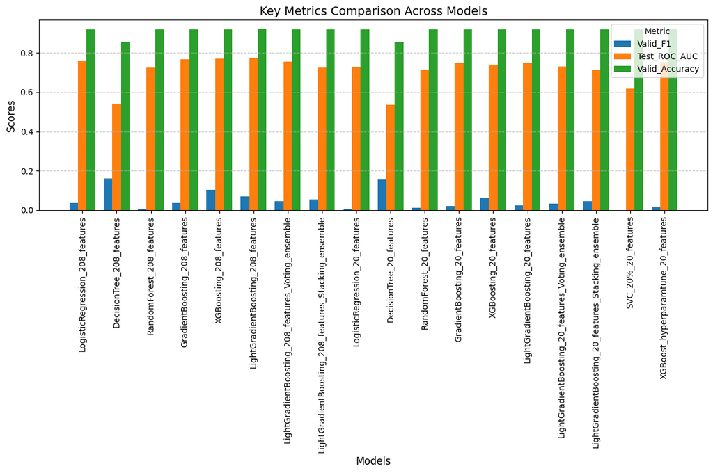

```python
# Metrics to plot
metrics_to_plot = ["Valid_F1", "Test_ROC_AUC", "Valid_Accuracy"]

# Create the plot
fig, ax = plt.subplots(figsize=(12, 8))

# X-axis positions for the models
x = np.arange(len(expLog["Experiment_Name"]))

# Bar width
width = 0.25

# Plot each metric
for i, metric in enumerate(metrics_to_plot):
    ax.bar(x + i * width, expLog[metric], width, label=metric)

# Add plot details
ax.set_xlabel("Models", fontsize=12)
ax.set_ylabel("Scores", fontsize=12)
ax.set_title("Key Metrics Comparison Across Models", fontsize=14)
ax.set_xticks(x + width)
ax.set_xticklabels(expLog["Experiment_Name"], rotation=90)
ax.legend(title="Metric", fontsize=10)
ax.grid(axis="y", linestyle="--", alpha=0.7)

# Optimize layout and display the plot
plt.tight_layout()
plt.show()
```

```python
# Sort expLog by Test_ROC_AUC in descending order and select the top 5 models
top_models_roc = expLog.sort_values(by="Test_ROC_AUC", ascending=False).head(5)
top_models_roc
```

|  | Experiment_Name | Train_Accuracy | Valid_Accuracy | Test_Accuracy | Train_ROC_AUC | Valid_ROC_AUC | Test_ROC_AUC | Train_Precision | Valid_Precision | Test_Precision | Train_Recall | Valid_Recall | Test_Recall | Train_F1 | Valid_F1 | Test_F1 | Train_Log_Loss | Valid_Log_Loss | Test_Log_Loss |
| --- | --- | --- | --- | --- | --- | --- | --- | --- | --- | --- | --- | --- | --- | --- | --- | --- | --- | --- | --- |
| 5 | LightGradientBoosting_208_features | 0.9225 | 0.9204 | 0.9165 | 0.8249 | 0.7743 | 0.7739 | 0.7655 | 0.5966 | 0.5538 | 0.0491 | 0.0374 | 0.0313 | 0.0923 | 0.0704 | 0.0592 | 0.2229 | 0.2404 | 0.2491 |
| 4 | XGBoosting_208_features | 0.9291 | 0.9192 | 0.9149 | 0.8847 | 0.7647 | 0.7688 | 0.8561 | 0.4910 | 0.4357 | 0.1395 | 0.0584 | 0.0452 | 0.2400 | 0.1044 | 0.0820 | 0.1940 | 0.2448 | 0.2523 |
| 3 | GradientBoosting_208_features | 0.9208 | 0.9198 | 0.9162 | 0.7784 | 0.7656 | 0.7678 | 0.6870 | 0.5645 | 0.5357 | 0.0228 | 0.0188 | 0.0182 | 0.0441 | 0.0364 | 0.0352 | 0.2394 | 0.2437 | 0.2518 |
| 0 | LogisticRegression_208_features | 0.9197 | 0.9197 | 0.9160 | 0.7608 | 0.7537 | 0.7594 | 0.4870 | 0.5448 | 0.4955 | 0.0179 | 0.0196 | 0.0167 | 0.0345 | 0.0379 | 0.0323 | 0.2451 | 0.2478 | 0.2540 |
| 6 | LightGradientBoosting_208_features_Voting_ense... | 0.9340 | 0.9199 | 0.9163 | 0.9994 | 0.7538 | 0.7554 | 1.0000 | 0.5660 | 0.5385 | 0.1765 | 0.0242 | 0.0234 | 0.3000 | 0.0464 | 0.0448 | 0.1231 | 0.2491 | 0.2571 |

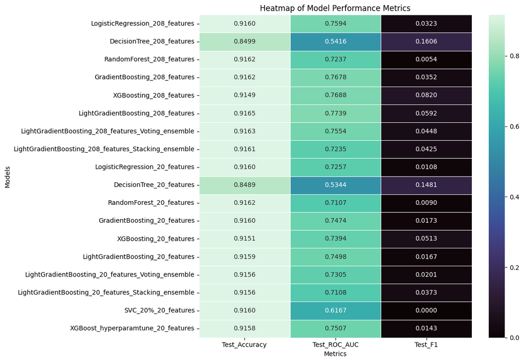

```python
import seaborn as sns

# Select relevant columns for the heatmap
heatmap_data = expLog[["Experiment_Name", "Test_Accuracy", "Test_ROC_AUC", "Test_F1"]].set_index("Experiment_Name")

# Create the heatmap
plt.figure(figsize=(12, 8))
sns.heatmap(heatmap_data, annot=True, cmap="mako", fmt=".4f", linewidths=0.5)
plt.title("Heatmap of Model Performance Metrics")
plt.ylabel("Models")
plt.xlabel("Metrics")
plt.tight_layout()
plt.show()
```

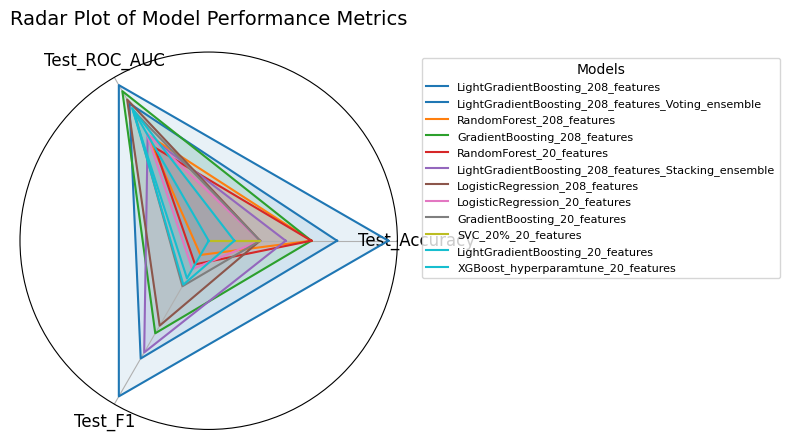

```python
from math import pi

# Select a subset of top-performing models based on Test_Accuracy (you can choose other metrics as well)
top_models = expLog.nlargest(12, "Test_Accuracy")  # Adjust the number as needed
categories = ["Test_Accuracy", "Test_ROC_AUC", "Test_F1"]
values = top_models[categories].values
experiment_names = top_models["Experiment_Name"].values

# Normalize values to [0, 1] range
normalized_values = (values - values.min(axis=0)) / (values.max(axis=0) - values.min(axis=0))

# Create the radar plot
fig, ax = plt.subplots(figsize=(8, 8), subplot_kw={"polar": True})

# Number of variables
num_vars = len(categories)
angles = [n / float(num_vars) * 2 * pi for n in range(num_vars)]
angles += angles[:1]  # Close the circle

# Set a colormap for better aesthetics
colors = plt.cm.get_cmap("tab10", len(experiment_names))

# Plot for each model
for i, (model_values, label) in enumerate(zip(normalized_values, experiment_names)):
    data = list(model_values) + list(model_values[:1])  # Close the circle
    ax.plot(angles, data, label=label, color=colors(i))
    ax.fill(angles, data, alpha=0.1, color=colors(i))

# Add labels
ax.set_yticks([])
ax.set_xticks(angles[:-1])
ax.set_xticklabels(categories, fontsize=12)
plt.title("Radar Plot of Model Performance Metrics", fontsize=14, pad=20)

# Move the legend outside the plot
plt.legend(loc="upper left", bbox_to_anchor=(1.05, 1), fontsize=8, title="Models")
plt.tight_layout()
plt.show()
```

### **3.5 Deep Learning Implementation: Multi-layer perception (MLP) model in PyTorch for loan default classification in PyTorch Lighting**

### **3.5.1 Initial MLP test**

The experiment was conducted on a data split, including training, validation, and test datasets. A dynamic LightningDataModule handled data loading, ensuring scalability and reproducibility. For training, we employed the Adam optimizer with a learning rate of 0.001 and monitored the validation accuracy to save the best-performing model via a checkpoint callback.

The model was trained over 20 epochs using an appropriate batch size (64). The training process utilized GPU acceleration to improve computational efficiency. Post-training, the best model checkpoint was reloaded and evaluated on the test set, achieving competitive results.

TensorBoard was used to monitor training metrics, providing insights into the model’s learning process.

```python
# Install necessary dependencies
!pip install pytorch-lightning torch torchvision torchmetrics
```

```
Downloading pytorch_lightning-2.4.0-py3-none-any.whl (815 kB)
   ━━━━━━━━━━━━━━━━━━━━━━━━━━━━━━━━━━━━━━━━ 815.2/815.2 kB 13.1 MB/s eta 0:00:00
Downloading torchmetrics-1.6.0-py3-none-any.whl (926 kB)
   ━━━━━━━━━━━━━━━━━━━━━━━━━━━━━━━━━━━━━━━━ 926.4/926.4 kB 39.1 MB/s eta 0:00:00
Downloading lightning_utilities-0.11.9-py3-none-any.whl (28 kB)
```

```python
import pytorch_lightning as pl
import torch
import torch.nn as nn
from torchmetrics import Accuracy
from torchmetrics.functional import precision, recall, f1_score, auroc
from pkg_resources import parse_version
from torchmetrics import __version__ as torchmetrics_version

class MultiLayerPerceptron(pl.LightningModule):
    def __init__(self, input_dim, hidden_units=(64, 32)):
        super().__init__()

        # Define accuracy metrics based on PyTorch Lightning version
        if parse_version(torchmetrics_version) > parse_version("0.8"):
            self.train_acc = Accuracy(task="multiclass", num_classes=2)  # Adjust num_classes
            self.valid_acc = Accuracy(task="multiclass", num_classes=2)
            self.test_acc = Accuracy(task="multiclass", num_classes=2)
        else:
            self.train_acc = Accuracy()
            self.valid_acc = Accuracy()
            self.test_acc = Accuracy()

        # Define MLP architecture
        all_layers = [nn.Flatten()]
        for hidden_unit in hidden_units:
            all_layers.append(nn.Linear(input_dim, hidden_unit))
            all_layers.append(nn.ReLU())
            input_dim = hidden_unit
        all_layers.append(nn.Linear(hidden_units[-1], 2))  # Output layer for binary classification
        self.model = nn.Sequential(*all_layers)

    def forward(self, x):
        return self.model(x)

    def training_step(self, batch, batch_idx):
        x, y = batch
        logits = self(x)
        loss = nn.functional.cross_entropy(logits, y)
        preds = torch.argmax(logits, dim=1)
        self.train_acc.update(preds, y)
        self.log("train_loss", loss, prog_bar=True)
        self.log("train_acc", self.train_acc.compute(), prog_bar=True)  # Log train accuracy

        train_precision = precision(preds, y, task="binary")
        train_recall = recall(preds, y, task="binary")
        train_f1 = f1_score(preds, y, task="binary")
        train_roc_auc = auroc(logits.softmax(dim=-1)[:, 1], y, task="binary")
        self.log("train_precision", train_precision, prog_bar=True)
        self.log("train_recall", train_recall, prog_bar=True)
        self.log("train_f1", train_f1, prog_bar=True)
        self.log("train_roc_auc", train_roc_auc, prog_bar=True)

        return loss

    def validation_step(self, batch, batch_idx):
        x, y = batch
        logits = self(x)
        loss = nn.functional.cross_entropy(logits, y)
        preds = torch.argmax(logits, dim=1)
        self.valid_acc.update(preds, y)
        self.log("valid_loss", loss, prog_bar=True)
        self.log("valid_acc", self.valid_acc.compute(), prog_bar=True)  # Log validation accuracy

        valid_precision = precision(preds, y, task="binary")
        valid_recall = recall(preds, y, task="binary")
        valid_f1 = f1_score(preds, y, task="binary")
        valid_roc_auc = auroc(logits.softmax(dim=-1)[:, 1], y, task="binary")
        self.log("valid_precision", valid_precision, prog_bar=True)
        self.log("valid_recall", valid_recall, prog_bar=True)
        self.log("valid_f1", valid_f1, prog_bar=True)
        self.log("valid_roc_auc", valid_roc_auc, prog_bar=True)

        return loss

    def test_step(self, batch, batch_idx):
        x, y = batch
        logits = self(x)
        loss = nn.functional.cross_entropy(logits, y)
        preds = torch.argmax(logits, dim=1)
        self.test_acc.update(preds, y)
        self.log("test_loss", loss, prog_bar=True)
        self.log("test_acc", self.test_acc.compute(), prog_bar=True)  # Log test accuracy

        test_precision = precision(preds, y, task="binary")
        test_recall = recall(preds, y, task="binary")
        test_f1 = f1_score(preds, y, task="binary")
        test_roc_auc = auroc(logits.softmax(dim=-1)[:, 1], y, task="binary")
        self.log("test_precision", test_precision, prog_bar=True)
        self.log("test_recall", test_recall, prog_bar=True)
        self.log("test_f1", test_f1, prog_bar=True)
        self.log("test_roc_auc", test_roc_auc, prog_bar=True)


        return loss

    def configure_optimizers(self):
        return torch.optim.Adam(self.parameters(), lr=0.001)
```

```python
from torch.utils.data import DataLoader, TensorDataset, random_split

#TODO: make sure this data has been scaled in the preprocessor that generated it
# from sklearn.preprocessing import StandardScaler
# scaler = StandardScaler()
# X_train_reduced = pd.DataFrame(scaler.fit_transform(X_train_reduced), columns=X_train_reduced.columns)
# X_test_reduced = pd.DataFrame(scaler.transform(X_test_reduced), columns=X_test_reduced.columns)

# Convert your train/test data into PyTorch tensors
X_train_tensor = torch.tensor(X_train_reduced.values, dtype=torch.float32)
y_train_tensor = torch.tensor(y_train.values, dtype=torch.long)
X_test_tensor = torch.tensor(X_test_reduced.values, dtype=torch.float32)
X_kaggle_test_tensor = torch.tensor(X_test_reduced.values, dtype=torch.float32)
y_test_tensor = torch.tensor(y_test.values, dtype=torch.long)

# Create datasets
dataset = TensorDataset(X_train_tensor, y_train_tensor)
train_size = int(0.8 * len(dataset))
val_size = len(dataset) - train_size
train_dataset, val_dataset = random_split(dataset, [train_size, val_size])
test_dataset = TensorDataset(X_test_tensor, y_test_tensor)

# Create dataloaders
batch_size = 64
train_loader = DataLoader(train_dataset, batch_size=batch_size, shuffle=True)
val_loader = DataLoader(val_dataset, batch_size=batch_size)
test_loader = DataLoader(test_dataset, batch_size=batch_size)
```

```python
class CustomDataModule(pl.LightningDataModule):
    def __init__(self, X_train, X_test, y_train, y_test, batch_size=64):
        super().__init__()
        self.X_train = X_train
        self.X_test = X_test
        self.y_train = y_train
        self.y_test = y_test
        self.batch_size = batch_size
        self.input_dim = X_train.shape[1]  # Automatically determine input_dim

    def setup(self, stage=None):
        # Split training data into training and validation sets
        dataset = TensorDataset(torch.tensor(self.X_train.values, dtype=torch.float32),
                                 torch.tensor(self.y_train.values, dtype=torch.long))
        train_size = int(0.8 * len(dataset))
        val_size = len(dataset) - train_size
        self.train_dataset, self.val_dataset = random_split(dataset, [train_size, val_size])

        # Prepare test dataset
        self.test_dataset = TensorDataset(torch.tensor(self.X_test.values, dtype=torch.float32),
                                          torch.tensor(self.y_test.values, dtype=torch.long))

    def train_dataloader(self):
        return DataLoader(self.train_dataset, batch_size=self.batch_size, shuffle=True)

    def val_dataloader(self):
        return DataLoader(self.val_dataset, batch_size=self.batch_size)

    def test_dataloader(self):
        return DataLoader(self.test_dataset, batch_size=self.batch_size)
```

```python
batch_size = 64
data_module = CustomDataModule(X_train_reduced, X_test_reduced, y_train, y_test, batch_size=batch_size)
```

```python
from pytorch_lightning.callbacks import ModelCheckpoint

# Initialize the model
input_dim = data_module.input_dim  # Dynamically fetched from the DataModule
mlp_model = MultiLayerPerceptron(input_dim=input_dim, hidden_units=(64, 32))

# Define callbacks
checkpoint_callback = ModelCheckpoint(
    monitor="valid_acc", mode="max", save_top_k=1, verbose=True
)


# Define trainer
trainer = pl.Trainer(
    max_epochs=20,
    callbacks=[checkpoint_callback],
    accelerator="gpu" if torch.cuda.is_available() else "cpu",
    devices=1 if torch.cuda.is_available() else None,
)


# Train the model
trainer.fit(mlp_model, datamodule=data_module)
```

```
INFO:pytorch_lightning.utilities.rank_zero:GPU available: True (cuda), used: True
INFO:pytorch_lightning.utilities.rank_zero:TPU available: False, using: 0 TPU cores
INFO:pytorch_lightning.utilities.rank_zero:HPU available: False, using: 0 HPUs
INFO:pytorch_lightning.accelerators.cuda:LOCAL_RANK: 0 - CUDA_VISIBLE_DEVICES: [0]
INFO:pytorch_lightning.callbacks.model_summary:
  | Name      | Type               | Params | Mode
---------------------------------------------------------
0 | train_acc | MulticlassAccuracy | 0      | train
1 | valid_acc | MulticlassAccuracy | 0      | train
2 | test_acc  | MulticlassAccuracy | 0      | train
3 | model     | Sequential         | 3.5 K  | train
---------------------------------------------------------
3.5 K     Trainable params
0         Non-trainable params
3.5 K     Total params
0.014     Total estimated model params size (MB)
10        Modules in train mode
0         Modules in eval mode
```

```
Sanity Checking: |          | 0/? [00:00<?, ?it/s]
```

```
Training: |          | 0/? [00:00<?, ?it/s]
```

```
Validation: |          | 0/? [00:00<?, ?it/s]
```

```
INFO:pytorch_lightning.utilities.rank_zero:Epoch 0, global step 2778: 'valid_acc' reached 0.91651 (best 0.91651), saving model to '/content/lightning_logs/version_0/checkpoints/epoch=0-step=2778.ckpt' as top 1
```

```
Validation: |          | 0/? [00:00<?, ?it/s]
```

```
INFO:pytorch_lightning.utilities.rank_zero:Epoch 1, global step 5556: 'valid_acc' reached 0.91902 (best 0.91902), saving model to '/content/lightning_logs/version_0/checkpoints/epoch=1-step=5556.ckpt' as top 1
```

```
Validation: |          | 0/? [00:00<?, ?it/s]
```

```
INFO:pytorch_lightning.utilities.rank_zero:Epoch 2, global step 8334: 'valid_acc' reached 0.91927 (best 0.91927), saving model to '/content/lightning_logs/version_0/checkpoints/epoch=2-step=8334.ckpt' as top 1
```

```
Validation: |          | 0/? [00:00<?, ?it/s]
```

```
INFO:pytorch_lightning.utilities.rank_zero:Epoch 3, global step 11112: 'valid_acc' reached 0.91935 (best 0.91935), saving model to '/content/lightning_logs/version_0/checkpoints/epoch=3-step=11112.ckpt' as top 1
```

```
Validation: |          | 0/? [00:00<?, ?it/s]
```

```
INFO:pytorch_lightning.utilities.rank_zero:Epoch 4, global step 13890: 'valid_acc' reached 0.91939 (best 0.91939), saving model to '/content/lightning_logs/version_0/checkpoints/epoch=4-step=13890.ckpt' as top 1
```

```
Validation: |          | 0/? [00:00<?, ?it/s]
```

```
INFO:pytorch_lightning.utilities.rank_zero:Epoch 5, global step 16668: 'valid_acc' reached 0.91942 (best 0.91942), saving model to '/content/lightning_logs/version_0/checkpoints/epoch=5-step=16668.ckpt' as top 1
```

```
Validation: |          | 0/? [00:00<?, ?it/s]
```

```
INFO:pytorch_lightning.utilities.rank_zero:Epoch 6, global step 19446: 'valid_acc' reached 0.91943 (best 0.91943), saving model to '/content/lightning_logs/version_0/checkpoints/epoch=6-step=19446.ckpt' as top 1
```

```
Validation: |          | 0/? [00:00<?, ?it/s]
```

```
INFO:pytorch_lightning.utilities.rank_zero:Epoch 7, global step 22224: 'valid_acc' reached 0.91945 (best 0.91945), saving model to '/content/lightning_logs/version_0/checkpoints/epoch=7-step=22224.ckpt' as top 1
```

```
Validation: |          | 0/? [00:00<?, ?it/s]
```

```
INFO:pytorch_lightning.utilities.rank_zero:Epoch 8, global step 25002: 'valid_acc' reached 0.91946 (best 0.91946), saving model to '/content/lightning_logs/version_0/checkpoints/epoch=8-step=25002.ckpt' as top 1
```

```
Validation: |          | 0/? [00:00<?, ?it/s]
```

```
INFO:pytorch_lightning.utilities.rank_zero:Epoch 9, global step 27780: 'valid_acc' reached 0.91949 (best 0.91949), saving model to '/content/lightning_logs/version_0/checkpoints/epoch=9-step=27780.ckpt' as top 1
```

```
Validation: |          | 0/? [00:00<?, ?it/s]
```

```
INFO:pytorch_lightning.utilities.rank_zero:Epoch 10, global step 30558: 'valid_acc' reached 0.91950 (best 0.91950), saving model to '/content/lightning_logs/version_0/checkpoints/epoch=10-step=30558.ckpt' as top 1
```

```
Validation: |          | 0/? [00:00<?, ?it/s]
```

```
INFO:pytorch_lightning.utilities.rank_zero:Epoch 11, global step 33336: 'valid_acc' reached 0.91951 (best 0.91951), saving model to '/content/lightning_logs/version_0/checkpoints/epoch=11-step=33336.ckpt' as top 1
```

```
Validation: |          | 0/? [00:00<?, ?it/s]
```

```
INFO:pytorch_lightning.utilities.rank_zero:Epoch 12, global step 36114: 'valid_acc' reached 0.91953 (best 0.91953), saving model to '/content/lightning_logs/version_0/checkpoints/epoch=12-step=36114.ckpt' as top 1
```

```
Validation: |          | 0/? [00:00<?, ?it/s]
```

```
INFO:pytorch_lightning.utilities.rank_zero:Epoch 13, global step 38892: 'valid_acc' reached 0.91955 (best 0.91955), saving model to '/content/lightning_logs/version_0/checkpoints/epoch=13-step=38892.ckpt' as top 1
```

```
Validation: |          | 0/? [00:00<?, ?it/s]
```

```
INFO:pytorch_lightning.utilities.rank_zero:Epoch 14, global step 41670: 'valid_acc' was not in top 1
```

```
Validation: |          | 0/? [00:00<?, ?it/s]
```

```
INFO:pytorch_lightning.utilities.rank_zero:Epoch 15, global step 44448: 'valid_acc' was not in top 1
```

```
Validation: |          | 0/? [00:00<?, ?it/s]
```

```
INFO:pytorch_lightning.utilities.rank_zero:Epoch 16, global step 47226: 'valid_acc' was not in top 1
```

```
Validation: |          | 0/? [00:00<?, ?it/s]
```

```
INFO:pytorch_lightning.utilities.rank_zero:Epoch 17, global step 50004: 'valid_acc' was not in top 1
```

```
Validation: |          | 0/? [00:00<?, ?it/s]
```

```
INFO:pytorch_lightning.utilities.rank_zero:Epoch 18, global step 52782: 'valid_acc' was not in top 1
```

```
Validation: |          | 0/? [00:00<?, ?it/s]
```

```
INFO:pytorch_lightning.utilities.rank_zero:Epoch 19, global step 55560: 'valid_acc' was not in top 1
INFO:pytorch_lightning.utilities.rank_zero:`Trainer.fit` stopped: `max_epochs=20` reached.
```

```python
#Use with CARE in case you want to delete the experiments. To delete specific experiment check out version in lightning logs
#%tensorboard --stop
# import shutil

# # Delete the lightning_logs directory
# log_dir = "lightning_logs"
# shutil.rmtree(log_dir, ignore_errors=True)

# print(f"Deleted {log_dir} directory.")
```

```python
# Start TensorBoard
%load_ext tensorboard
%tensorboard --logdir lightning_logs/
```

```python
# Save and load the best checkpoint
best_model_path = checkpoint_callback.best_model_path

# Load the model from the checkpoint using the input_dim from the DataModule
loaded_model = MultiLayerPerceptron.load_from_checkpoint(
    best_model_path,
    input_dim=data_module.input_dim,  # Dynamically fetched from the DataModule
    hidden_units=(64, 32)             # Use the same hidden_units as during training
)

# Evaluate the loaded model using the test dataloader from the DataModule
trainer.test(model=loaded_model, dataloaders=data_module.test_dataloader())
```

```
INFO:pytorch_lightning.accelerators.cuda:LOCAL_RANK: 0 - CUDA_VISIBLE_DEVICES: [0]
```

```
Testing: |          | 0/? [00:00<?, ?it/s]
```

```
┏━━━━━━━━━━━━━━━━━━━━━━━━━━━┳━━━━━━━━━━━━━━━━━━━━━━━━━━━┓
┃        Test metric        ┃       DataLoader 0        ┃
┡━━━━━━━━━━━━━━━━━━━━━━━━━━━╇━━━━━━━━━━━━━━━━━━━━━━━━━━━┩
│         test_acc          │    0.9176577925682068     │
│          test_f1          │   0.013031472451984882    │
│         test_loss         │    0.2614652216434479     │
│      test_precision       │    0.04488879814743996    │
│        test_recall        │   0.008030164986848831    │
│       test_roc_auc        │    0.7366999387741089     │
└───────────────────────────┴───────────────────────────┘
```

```
[{'test_loss': 0.2614652216434479,
  'test_acc': 0.9176577925682068,
  'test_precision': 0.04488879814743996,
  'test_recall': 0.008030164986848831,
  'test_f1': 0.013031472451984882,
  'test_roc_auc': 0.7366999387741089}]
```

```python
# Evaluate the model on the test dataset
results = trainer.test(model=loaded_model, dataloaders=data_module.test_dataloader(), verbose=False)

# Extract metrics
lightning_metrics = {
    "Experiment_Name": "Sparse Input MLP",  # Name your Lightning experiment
    "Test_Accuracy": results[0]["test_acc"],
    "Test_Loss": results[0]["test_loss"],
    "Test_Precision": results[0]["test_precision"],
    "Test_Recall": results[0]["test_recall"],
    "Test_ROC_AUC": results[0]["test_roc_auc"],
    "Test_F1": results[0]["test_f1"],
}

# Add missing metrics if not already logged
if lightning_metrics["Test_ROC_AUC"] is None:
    print("Warning: Test ROC AUC not logged in the Lightning model.")
if lightning_metrics["Test_F1"] is None:
    print("Warning: Test F1 not logged in the Lightning model.")
```

```
INFO:pytorch_lightning.accelerators.cuda:LOCAL_RANK: 0 - CUDA_VISIBLE_DEVICES: [0]
```

```
Testing: |          | 0/? [00:00<?, ?it/s]
```

```python
# Convert Lightning metrics to a DataFrame
lightning_df = pd.DataFrame([lightning_metrics])
```

```python
lightning_df
```

[output not shown]

```python
# Append the new row to the expLog DataFrame
#expLog = pd.concat([expLog, lightning_df], ignore_index=True)
```

### **3.5.2 Exploring Neural Network Architectures**

To evaluate performance, we tested four Multi-Layer Perceptron (MLP) architectures:

- **Sparse Input MLP:** A lightweight baseline with fewer neurons to benchmark performance against more complex models.
- **Simple Deep MLP:** Added depth (128, 64, 32 units) to capture complex patterns in the data.
- **MLP with Dropout:** Incorporated dropout (rate = 0.2) to mitigate overfitting, improving generalization.
- **Wider MLP:** Increased width (512, 256, 128 units) for greater representational power.

Results were systematically logged to compare accuracy, precision, recall, F1-score, and ROC-AUC, guiding architectural decisions.

```python
experiment_logs = []
```

```python
def run_experiment(model_name, hidden_units, dropout_rate=None):
    # Modify the architecture based on the experiment
    if dropout_rate:
        class DropoutMLP(MultiLayerPerceptron):
            def __init__(self, input_dim, hidden_units, dropout_rate):
                super().__init__(input_dim, hidden_units)
                layers = []
                for hidden_unit in hidden_units:
                    layers.append(nn.Linear(input_dim, hidden_unit))
                    layers.append(nn.ReLU())
                    layers.append(nn.Dropout(p=dropout_rate))
                    input_dim = hidden_unit
                layers.append(nn.Linear(hidden_units[-1], 2))  # Output layer
                self.model = nn.Sequential(*layers)
        model = DropoutMLP(input_dim=data_module.input_dim, hidden_units=hidden_units, dropout_rate=dropout_rate)
    else:
        model = MultiLayerPerceptron(input_dim=data_module.input_dim, hidden_units=hidden_units)

    # Train and test the model
    trainer = pl.Trainer(
        max_epochs=20,
        callbacks=[checkpoint_callback],
        accelerator="gpu" if torch.cuda.is_available() else "cpu",
        devices=1 if torch.cuda.is_available() else None,
    )
    trainer.fit(model, datamodule=data_module)
    results = trainer.test(model=model, dataloaders=data_module.test_dataloader(), verbose=False)

    # Log metrics
    metrics = {
        "Experiment_Name": model_name,
        "Hidden_Units": hidden_units,
        "Dropout_Rate": dropout_rate,
        "Test_Accuracy": results[0]["test_acc"],
        "Test_Loss": results[0]["test_loss"],
        "Test_Precision": results[0]["test_precision"],
        "Test_Recall": results[0]["test_recall"],
        "Test_ROC_AUC": results[0]["test_roc_auc"],
        "Test_F1": results[0]["test_f1"],
    }
    experiment_logs.append(metrics)
    print(f"Experiment {model_name} complete!")
```

```python
#Baseline
run_experiment("Sparse Input MLP", hidden_units=(64, 32))
```

```
INFO:pytorch_lightning.utilities.rank_zero:GPU available: True (cuda), used: True
INFO:pytorch_lightning.utilities.rank_zero:TPU available: False, using: 0 TPU cores
INFO:pytorch_lightning.utilities.rank_zero:HPU available: False, using: 0 HPUs
INFO:pytorch_lightning.accelerators.cuda:LOCAL_RANK: 0 - CUDA_VISIBLE_DEVICES: [0]
INFO:pytorch_lightning.callbacks.model_summary:
  | Name      | Type               | Params | Mode
---------------------------------------------------------
0 | train_acc | MulticlassAccuracy | 0      | train
1 | valid_acc | MulticlassAccuracy | 0      | train
2 | test_acc  | MulticlassAccuracy | 0      | train
3 | model     | Sequential         | 3.5 K  | train
---------------------------------------------------------
3.5 K     Trainable params
0         Non-trainable params
3.5 K     Total params
0.014     Total estimated model params size (MB)
10        Modules in train mode
0         Modules in eval mode
```

```
Sanity Checking: |          | 0/? [00:00<?, ?it/s]
```

```
Training: |          | 0/? [00:00<?, ?it/s]
```

```
Validation: |          | 0/? [00:00<?, ?it/s]
```

```
INFO:pytorch_lightning.utilities.rank_zero:Epoch 0, global step 2778: 'valid_acc' was not in top 1
```

```
Validation: |          | 0/? [00:00<?, ?it/s]
```

```
INFO:pytorch_lightning.utilities.rank_zero:Epoch 1, global step 5556: 'valid_acc' was not in top 1
```

```
Validation: |          | 0/? [00:00<?, ?it/s]
```

```
INFO:pytorch_lightning.utilities.rank_zero:Epoch 2, global step 8334: 'valid_acc' was not in top 1
```

```
Validation: |          | 0/? [00:00<?, ?it/s]
```

```
INFO:pytorch_lightning.utilities.rank_zero:Epoch 3, global step 11112: 'valid_acc' was not in top 1
```

```
Validation: |          | 0/? [00:00<?, ?it/s]
```

```
INFO:pytorch_lightning.utilities.rank_zero:Epoch 4, global step 13890: 'valid_acc' was not in top 1
```

```
Validation: |          | 0/? [00:00<?, ?it/s]
```

```
INFO:pytorch_lightning.utilities.rank_zero:Epoch 5, global step 16668: 'valid_acc' was not in top 1
```

```
Validation: |          | 0/? [00:00<?, ?it/s]
```

```
INFO:pytorch_lightning.utilities.rank_zero:Epoch 6, global step 19446: 'valid_acc' was not in top 1
```

```
Validation: |          | 0/? [00:00<?, ?it/s]
```

```
INFO:pytorch_lightning.utilities.rank_zero:Epoch 7, global step 22224: 'valid_acc' was not in top 1
```

```
Validation: |          | 0/? [00:00<?, ?it/s]
```

```
INFO:pytorch_lightning.utilities.rank_zero:Epoch 8, global step 25002: 'valid_acc' was not in top 1
```

```
Validation: |          | 0/? [00:00<?, ?it/s]
```

```
INFO:pytorch_lightning.utilities.rank_zero:Epoch 9, global step 27780: 'valid_acc' was not in top 1
```

```
Validation: |          | 0/? [00:00<?, ?it/s]
```

```
INFO:pytorch_lightning.utilities.rank_zero:Epoch 10, global step 30558: 'valid_acc' was not in top 1
```

```
Validation: |          | 0/? [00:00<?, ?it/s]
```

```
INFO:pytorch_lightning.utilities.rank_zero:Epoch 11, global step 33336: 'valid_acc' was not in top 1
```

```
Validation: |          | 0/? [00:00<?, ?it/s]
```

```
INFO:pytorch_lightning.utilities.rank_zero:Epoch 12, global step 36114: 'valid_acc' was not in top 1
```

```
Validation: |          | 0/? [00:00<?, ?it/s]
```

```
INFO:pytorch_lightning.utilities.rank_zero:Epoch 13, global step 38892: 'valid_acc' was not in top 1
```

```
Validation: |          | 0/? [00:00<?, ?it/s]
```

```
INFO:pytorch_lightning.utilities.rank_zero:Epoch 14, global step 41670: 'valid_acc' was not in top 1
```

```
Validation: |          | 0/? [00:00<?, ?it/s]
```

[output not shown]

```
INFO:pytorch_lightning.utilities.rank_zero:Epoch 16, global step 47226: 'valid_acc' was not in top 1
```

```
Validation: |          | 0/? [00:00<?, ?it/s]
```

```
INFO:pytorch_lightning.utilities.rank_zero:Epoch 17, global step 50004: 'valid_acc' was not in top 1
```

```
Validation: |          | 0/? [00:00<?, ?it/s]
```

```
INFO:pytorch_lightning.utilities.rank_zero:Epoch 18, global step 52782: 'valid_acc' was not in top 1
```

```
Validation: |          | 0/? [00:00<?, ?it/s]
```

```
INFO:pytorch_lightning.utilities.rank_zero:Epoch 19, global step 55560: 'valid_acc' was not in top 1
INFO:pytorch_lightning.utilities.rank_zero:`Trainer.fit` stopped: `max_epochs=20` reached.
INFO:pytorch_lightning.accelerators.cuda:LOCAL_RANK: 0 - CUDA_VISIBLE_DEVICES: [0]
```

```
Testing: |          | 0/? [00:00<?, ?it/s]
```

```
Experiment Sparse Input MLP complete!
```

```python
# Simple Deep MLP
run_experiment("Simple Deep MLP", hidden_units=(128, 64, 32))
```

```
INFO:pytorch_lightning.utilities.rank_zero:GPU available: True (cuda), used: True
INFO:pytorch_lightning.utilities.rank_zero:TPU available: False, using: 0 TPU cores
INFO:pytorch_lightning.utilities.rank_zero:HPU available: False, using: 0 HPUs
INFO:pytorch_lightning.accelerators.cuda:LOCAL_RANK: 0 - CUDA_VISIBLE_DEVICES: [0]
INFO:pytorch_lightning.callbacks.model_summary:
  | Name      | Type               | Params | Mode
---------------------------------------------------------
0 | train_acc | MulticlassAccuracy | 0      | train
1 | valid_acc | MulticlassAccuracy | 0      | train
2 | test_acc  | MulticlassAccuracy | 0      | train
3 | model     | Sequential         | 13.1 K | train
---------------------------------------------------------
13.1 K    Trainable params
0         Non-trainable params
13.1 K    Total params
0.052     Total estimated model params size (MB)
12        Modules in train mode
0         Modules in eval mode
```

```
Sanity Checking: |          | 0/? [00:00<?, ?it/s]
```

```
Training: |          | 0/? [00:00<?, ?it/s]
```

```
Validation: |          | 0/? [00:00<?, ?it/s]
```

```
INFO:pytorch_lightning.utilities.rank_zero:Epoch 0, global step 2778: 'valid_acc' was not in top 1
```

```
Validation: |          | 0/? [00:00<?, ?it/s]
```

```
INFO:pytorch_lightning.utilities.rank_zero:Epoch 1, global step 5556: 'valid_acc' was not in top 1
```

```
Validation: |          | 0/? [00:00<?, ?it/s]
```

```
INFO:pytorch_lightning.utilities.rank_zero:Epoch 2, global step 8334: 'valid_acc' was not in top 1
```

```
Validation: |          | 0/? [00:00<?, ?it/s]
```

```
INFO:pytorch_lightning.utilities.rank_zero:Epoch 3, global step 11112: 'valid_acc' was not in top 1
```

```
Validation: |          | 0/? [00:00<?, ?it/s]
```

```
INFO:pytorch_lightning.utilities.rank_zero:Epoch 4, global step 13890: 'valid_acc' was not in top 1
```

```
Validation: |          | 0/? [00:00<?, ?it/s]
```

```
INFO:pytorch_lightning.utilities.rank_zero:Epoch 5, global step 16668: 'valid_acc' was not in top 1
```

```
Validation: |          | 0/? [00:00<?, ?it/s]
```

```
INFO:pytorch_lightning.utilities.rank_zero:Epoch 6, global step 19446: 'valid_acc' was not in top 1
```

```
Validation: |          | 0/? [00:00<?, ?it/s]
```

```
INFO:pytorch_lightning.utilities.rank_zero:Epoch 7, global step 22224: 'valid_acc' was not in top 1
```

```
Validation: |          | 0/? [00:00<?, ?it/s]
```

```
INFO:pytorch_lightning.utilities.rank_zero:Epoch 8, global step 25002: 'valid_acc' was not in top 1
```

```
Validation: |          | 0/? [00:00<?, ?it/s]
```

```
INFO:pytorch_lightning.utilities.rank_zero:Epoch 9, global step 27780: 'valid_acc' was not in top 1
```

```
Validation: |          | 0/? [00:00<?, ?it/s]
```

```
INFO:pytorch_lightning.utilities.rank_zero:Epoch 10, global step 30558: 'valid_acc' was not in top 1
```

```
Validation: |          | 0/? [00:00<?, ?it/s]
```

```
INFO:pytorch_lightning.utilities.rank_zero:Epoch 11, global step 33336: 'valid_acc' was not in top 1
```

```
Validation: |          | 0/? [00:00<?, ?it/s]
```

```
INFO:pytorch_lightning.utilities.rank_zero:Epoch 12, global step 36114: 'valid_acc' was not in top 1
```

```
Validation: |          | 0/? [00:00<?, ?it/s]
```

```
INFO:pytorch_lightning.utilities.rank_zero:Epoch 13, global step 38892: 'valid_acc' was not in top 1
```

```
Validation: |          | 0/? [00:00<?, ?it/s]
```

```
INFO:pytorch_lightning.utilities.rank_zero:Epoch 14, global step 41670: 'valid_acc' was not in top 1
```

```
Validation: |          | 0/? [00:00<?, ?it/s]
```

[output not shown]

```
INFO:pytorch_lightning.utilities.rank_zero:Epoch 16, global step 47226: 'valid_acc' was not in top 1
```

```
Validation: |          | 0/? [00:00<?, ?it/s]
```

```
INFO:pytorch_lightning.utilities.rank_zero:Epoch 17, global step 50004: 'valid_acc' was not in top 1
```

```
Validation: |          | 0/? [00:00<?, ?it/s]
```

```
INFO:pytorch_lightning.utilities.rank_zero:Epoch 18, global step 52782: 'valid_acc' was not in top 1
```

```
Validation: |          | 0/? [00:00<?, ?it/s]
```

```
INFO:pytorch_lightning.utilities.rank_zero:Epoch 19, global step 55560: 'valid_acc' was not in top 1
INFO:pytorch_lightning.utilities.rank_zero:`Trainer.fit` stopped: `max_epochs=20` reached.
INFO:pytorch_lightning.accelerators.cuda:LOCAL_RANK: 0 - CUDA_VISIBLE_DEVICES: [0]
```

```
Testing: |          | 0/? [00:00<?, ?it/s]
```

```
Experiment Simple Deep MLP complete!
```

```python
# MLP with dropout
run_experiment("MLP with Dropout", hidden_units=(128, 64, 32), dropout_rate=0.2)
```

```
INFO:pytorch_lightning.utilities.rank_zero:GPU available: True (cuda), used: True
INFO:pytorch_lightning.utilities.rank_zero:TPU available: False, using: 0 TPU cores
INFO:pytorch_lightning.utilities.rank_zero:HPU available: False, using: 0 HPUs
INFO:pytorch_lightning.accelerators.cuda:LOCAL_RANK: 0 - CUDA_VISIBLE_DEVICES: [0]
INFO:pytorch_lightning.callbacks.model_summary:
  | Name      | Type               | Params | Mode
---------------------------------------------------------
0 | train_acc | MulticlassAccuracy | 0      | train
1 | valid_acc | MulticlassAccuracy | 0      | train
2 | test_acc  | MulticlassAccuracy | 0      | train
3 | model     | Sequential         | 13.1 K | train
---------------------------------------------------------
13.1 K    Trainable params
0         Non-trainable params
13.1 K    Total params
0.052     Total estimated model params size (MB)
14        Modules in train mode
0         Modules in eval mode
```

```
Sanity Checking: |          | 0/? [00:00<?, ?it/s]
```

```
Training: |          | 0/? [00:00<?, ?it/s]
```

```
Validation: |          | 0/? [00:00<?, ?it/s]
```

```
INFO:pytorch_lightning.utilities.rank_zero:Epoch 0, global step 2778: 'valid_acc' reached 0.92138 (best 0.92138), saving model to '/content/lightning_logs/version_1/checkpoints/epoch=0-step=2778.ckpt' as top 1
```

```
Validation: |          | 0/? [00:00<?, ?it/s]
```

```
INFO:pytorch_lightning.utilities.rank_zero:Epoch 1, global step 5556: 'valid_acc' reached 0.92181 (best 0.92181), saving model to '/content/lightning_logs/version_1/checkpoints/epoch=1-step=5556.ckpt' as top 1
```

```
Validation: |          | 0/? [00:00<?, ?it/s]
```

```
INFO:pytorch_lightning.utilities.rank_zero:Epoch 2, global step 8334: 'valid_acc' reached 0.92194 (best 0.92194), saving model to '/content/lightning_logs/version_1/checkpoints/epoch=2-step=8334.ckpt' as top 1
```

```
Validation: |          | 0/? [00:00<?, ?it/s]
```

```
INFO:pytorch_lightning.utilities.rank_zero:Epoch 3, global step 11112: 'valid_acc' reached 0.92200 (best 0.92200), saving model to '/content/lightning_logs/version_1/checkpoints/epoch=3-step=11112.ckpt' as top 1
```

```
Validation: |          | 0/? [00:00<?, ?it/s]
```

```
INFO:pytorch_lightning.utilities.rank_zero:Epoch 4, global step 13890: 'valid_acc' reached 0.92204 (best 0.92204), saving model to '/content/lightning_logs/version_1/checkpoints/epoch=4-step=13890.ckpt' as top 1
```

```
Validation: |          | 0/? [00:00<?, ?it/s]
```

```
INFO:pytorch_lightning.utilities.rank_zero:Epoch 5, global step 16668: 'valid_acc' reached 0.92206 (best 0.92206), saving model to '/content/lightning_logs/version_1/checkpoints/epoch=5-step=16668.ckpt' as top 1
```

```
Validation: |          | 0/? [00:00<?, ?it/s]
```

```
INFO:pytorch_lightning.utilities.rank_zero:Epoch 6, global step 19446: 'valid_acc' reached 0.92209 (best 0.92209), saving model to '/content/lightning_logs/version_1/checkpoints/epoch=6-step=19446.ckpt' as top 1
```

```
Validation: |          | 0/? [00:00<?, ?it/s]
```

```
INFO:pytorch_lightning.utilities.rank_zero:Epoch 7, global step 22224: 'valid_acc' reached 0.92210 (best 0.92210), saving model to '/content/lightning_logs/version_1/checkpoints/epoch=7-step=22224.ckpt' as top 1
```

```
Validation: |          | 0/? [00:00<?, ?it/s]
```

```
INFO:pytorch_lightning.utilities.rank_zero:Epoch 8, global step 25002: 'valid_acc' reached 0.92211 (best 0.92211), saving model to '/content/lightning_logs/version_1/checkpoints/epoch=8-step=25002.ckpt' as top 1
```

```
Validation: |          | 0/? [00:00<?, ?it/s]
```

```
INFO:pytorch_lightning.utilities.rank_zero:Epoch 9, global step 27780: 'valid_acc' reached 0.92212 (best 0.92212), saving model to '/content/lightning_logs/version_1/checkpoints/epoch=9-step=27780.ckpt' as top 1
```

```
Validation: |          | 0/? [00:00<?, ?it/s]
```

```
INFO:pytorch_lightning.utilities.rank_zero:Epoch 10, global step 30558: 'valid_acc' reached 0.92213 (best 0.92213), saving model to '/content/lightning_logs/version_1/checkpoints/epoch=10-step=30558.ckpt' as top 1
```

```
Validation: |          | 0/? [00:00<?, ?it/s]
```

```
INFO:pytorch_lightning.utilities.rank_zero:Epoch 11, global step 33336: 'valid_acc' was not in top 1
```

```
Validation: |          | 0/? [00:00<?, ?it/s]
```

```
INFO:pytorch_lightning.utilities.rank_zero:Epoch 12, global step 36114: 'valid_acc' was not in top 1
```

```
Validation: |          | 0/? [00:00<?, ?it/s]
```

```
INFO:pytorch_lightning.utilities.rank_zero:Epoch 13, global step 38892: 'valid_acc' reached 0.92213 (best 0.92213), saving model to '/content/lightning_logs/version_1/checkpoints/epoch=13-step=38892.ckpt' as top 1
```

```
Validation: |          | 0/? [00:00<?, ?it/s]
```

```
INFO:pytorch_lightning.utilities.rank_zero:Epoch 14, global step 41670: 'valid_acc' reached 0.92213 (best 0.92213), saving model to '/content/lightning_logs/version_1/checkpoints/epoch=14-step=41670.ckpt' as top 1
```

```
Validation: |          | 0/? [00:00<?, ?it/s]
```

```
INFO:pytorch_lightning.utilities.rank_zero:Epoch 15, global step 44448: 'valid_acc' reached 0.92214 (best 0.92214), saving model to '/content/lightning_logs/version_1/checkpoints/epoch=15-step=44448.ckpt' as top 1
```

```
Validation: |          | 0/? [00:00<?, ?it/s]
```

```
INFO:pytorch_lightning.utilities.rank_zero:Epoch 16, global step 47226: 'valid_acc' reached 0.92214 (best 0.92214), saving model to '/content/lightning_logs/version_1/checkpoints/epoch=16-step=47226.ckpt' as top 1
```

```
Validation: |          | 0/? [00:00<?, ?it/s]
```

```
INFO:pytorch_lightning.utilities.rank_zero:Epoch 17, global step 50004: 'valid_acc' reached 0.92214 (best 0.92214), saving model to '/content/lightning_logs/version_1/checkpoints/epoch=17-step=50004.ckpt' as top 1
```

```
Validation: |          | 0/? [00:00<?, ?it/s]
```

```
INFO:pytorch_lightning.utilities.rank_zero:Epoch 18, global step 52782: 'valid_acc' was not in top 1
```

```
Validation: |          | 0/? [00:00<?, ?it/s]
```

```
INFO:pytorch_lightning.utilities.rank_zero:Epoch 19, global step 55560: 'valid_acc' reached 0.92214 (best 0.92214), saving model to '/content/lightning_logs/version_1/checkpoints/epoch=19-step=55560.ckpt' as top 1
INFO:pytorch_lightning.utilities.rank_zero:`Trainer.fit` stopped: `max_epochs=20` reached.
INFO:pytorch_lightning.accelerators.cuda:LOCAL_RANK: 0 - CUDA_VISIBLE_DEVICES: [0]
```

```
Testing: |          | 0/? [00:00<?, ?it/s]
```

```
Experiment MLP with Dropout complete!
```

```python
# Wider MLP
run_experiment("Wider MLP", hidden_units=(512, 256, 128))
```

```
INFO:pytorch_lightning.utilities.rank_zero:GPU available: True (cuda), used: True
INFO:pytorch_lightning.utilities.rank_zero:TPU available: False, using: 0 TPU cores
INFO:pytorch_lightning.utilities.rank_zero:HPU available: False, using: 0 HPUs
INFO:pytorch_lightning.accelerators.cuda:LOCAL_RANK: 0 - CUDA_VISIBLE_DEVICES: [0]
INFO:pytorch_lightning.callbacks.model_summary:
  | Name      | Type               | Params | Mode
---------------------------------------------------------
0 | train_acc | MulticlassAccuracy | 0      | train
1 | valid_acc | MulticlassAccuracy | 0      | train
2 | test_acc  | MulticlassAccuracy | 0      | train
3 | model     | Sequential         | 175 K  | train
---------------------------------------------------------
175 K     Trainable params
0         Non-trainable params
175 K     Total params
0.701     Total estimated model params size (MB)
12        Modules in train mode
0         Modules in eval mode
```

```
Sanity Checking: |          | 0/? [00:00<?, ?it/s]
```

```
Training: |          | 0/? [00:00<?, ?it/s]
```

```
Validation: |          | 0/? [00:00<?, ?it/s]
```

```
INFO:pytorch_lightning.utilities.rank_zero:Epoch 0, global step 2778: 'valid_acc' was not in top 1
```

```
Validation: |          | 0/? [00:00<?, ?it/s]
```

```
INFO:pytorch_lightning.utilities.rank_zero:Epoch 1, global step 5556: 'valid_acc' was not in top 1
```

```
Validation: |          | 0/? [00:00<?, ?it/s]
```

```
INFO:pytorch_lightning.utilities.rank_zero:Epoch 2, global step 8334: 'valid_acc' was not in top 1
```

```
Validation: |          | 0/? [00:00<?, ?it/s]
```

```
INFO:pytorch_lightning.utilities.rank_zero:Epoch 3, global step 11112: 'valid_acc' was not in top 1
```

```
Validation: |          | 0/? [00:00<?, ?it/s]
```

```
INFO:pytorch_lightning.utilities.rank_zero:Epoch 4, global step 13890: 'valid_acc' was not in top 1
```

```
Validation: |          | 0/? [00:00<?, ?it/s]
```

```
INFO:pytorch_lightning.utilities.rank_zero:Epoch 5, global step 16668: 'valid_acc' was not in top 1
```

```
Validation: |          | 0/? [00:00<?, ?it/s]
```

```
INFO:pytorch_lightning.utilities.rank_zero:Epoch 6, global step 19446: 'valid_acc' was not in top 1
```

```
Validation: |          | 0/? [00:00<?, ?it/s]
```

```
INFO:pytorch_lightning.utilities.rank_zero:Epoch 7, global step 22224: 'valid_acc' was not in top 1
```

```
Validation: |          | 0/? [00:00<?, ?it/s]
```

```
INFO:pytorch_lightning.utilities.rank_zero:Epoch 8, global step 25002: 'valid_acc' was not in top 1
```

```
Validation: |          | 0/? [00:00<?, ?it/s]
```

```
INFO:pytorch_lightning.utilities.rank_zero:Epoch 9, global step 27780: 'valid_acc' was not in top 1
```

```
Validation: |          | 0/? [00:00<?, ?it/s]
```

```
INFO:pytorch_lightning.utilities.rank_zero:Epoch 10, global step 30558: 'valid_acc' was not in top 1
```

```
Validation: |          | 0/? [00:00<?, ?it/s]
```

```
INFO:pytorch_lightning.utilities.rank_zero:Epoch 11, global step 33336: 'valid_acc' was not in top 1
```

```
Validation: |          | 0/? [00:00<?, ?it/s]
```

```
INFO:pytorch_lightning.utilities.rank_zero:Epoch 12, global step 36114: 'valid_acc' was not in top 1
```

```
Validation: |          | 0/? [00:00<?, ?it/s]
```

```
INFO:pytorch_lightning.utilities.rank_zero:Epoch 13, global step 38892: 'valid_acc' was not in top 1
```

```
Validation: |          | 0/? [00:00<?, ?it/s]
```

```
INFO:pytorch_lightning.utilities.rank_zero:Epoch 14, global step 41670: 'valid_acc' was not in top 1
```

```
Validation: |          | 0/? [00:00<?, ?it/s]
```

```
INFO:pytorch_lightning.utilities.rank_zero:Epoch 15, global step 44448: 'valid_acc' was not in top 1
```

```
Validation: |          | 0/? [00:00<?, ?it/s]
```

```
INFO:pytorch_lightning.utilities.rank_zero:Epoch 16, global step 47226: 'valid_acc' was not in top 1
```

```
Validation: |          | 0/? [00:00<?, ?it/s]
```

```
INFO:pytorch_lightning.utilities.rank_zero:Epoch 17, global step 50004: 'valid_acc' was not in top 1
```

```
Validation: |          | 0/? [00:00<?, ?it/s]
```

```
INFO:pytorch_lightning.utilities.rank_zero:Epoch 18, global step 52782: 'valid_acc' was not in top 1
```

```
Validation: |          | 0/? [00:00<?, ?it/s]
```

[output not shown]

```
Testing: |          | 0/? [00:00<?, ?it/s]
```

```
Experiment Wider MLP complete!
```

```python
experiment_logs_df = pd.DataFrame(experiment_logs)

# Sort by Test_Accuracy
experiment_logs_df.sort_values(by="Test_Accuracy", ascending=False, inplace=True)
experiment_logs_df.to_csv("experiment_results.csv", index=False)
```

```python
experiment_logs_df.sort_index(inplace=True)
```

```python
experiment_logs_df
```

|  | Experiment_Name | Hidden_Units | Dropout_Rate | Test_Accuracy | Test_Loss | Test_Precision | Test_Recall | Test_ROC_AUC | Test_F1 |
| --- | --- | --- | --- | --- | --- | --- | --- | --- | --- |
| 0 | Sparse Input MLP | (64, 32) | NaN | 0.916809 | 0.260497 | 0.052234 | 0.009399 | 0.734491 | 0.015572 |
| 1 | Simple Deep MLP | (128, 64, 32) | NaN | 0.916515 | 0.264466 | 0.089778 | 0.017829 | 0.726044 | 0.028497 |
| 2 | MLP with Dropout | (128, 64, 32) | 0.2 | 0.917485 | 0.259675 | 0.008162 | 0.001123 | 0.737176 | 0.001959 |
| 3 | Wider MLP | (512, 256, 128) | NaN | 0.912624 | 0.280380 | 0.157213 | 0.041690 | 0.715157 | 0.062092 |

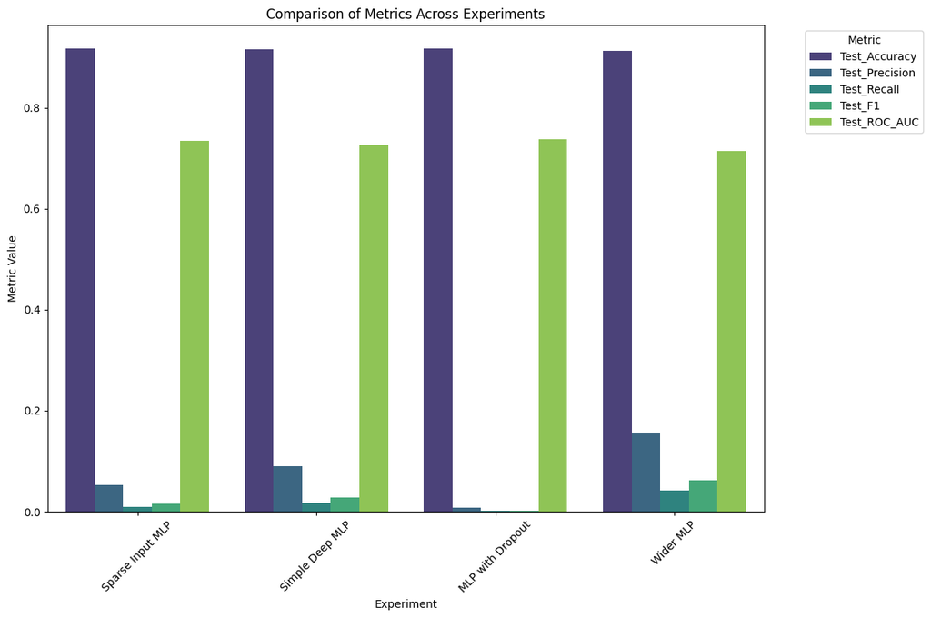

```python
# Melt the DataFrame to reshape it for grouped bar plotting
melted_logs = experiment_logs_df.melt(
    id_vars="Experiment_Name",
    value_vars=["Test_Accuracy", "Test_Precision", "Test_Recall", "Test_F1", "Test_ROC_AUC"],
    var_name="Metric",
    value_name="Value"
)

# Plot the metrics
plt.figure(figsize=(12, 8))
sns.barplot(
    data=melted_logs,
    x="Experiment_Name",
    y="Value",
    hue="Metric",
    palette="viridis"
)
plt.title("Comparison of Metrics Across Experiments")
plt.xlabel("Experiment")
plt.ylabel("Metric Value")
plt.xticks(rotation=45)
plt.legend(title="Metric", bbox_to_anchor=(1.05, 1), loc="upper left")
plt.tight_layout()
plt.show()
```

```python
# Start TensorBoard
%load_ext tensorboard
%tensorboard --logdir lightning_logs/
```

```
The tensorboard extension is already loaded. To reload it, use:
  %reload_ext tensorboard
```

```
Reusing TensorBoard on port 6006 (pid 123782), started 1:18:54 ago. (Use '!kill 123782' to kill it.)
```

```python
experiment_logs_df
```

|  | Experiment_Name | Hidden_Units | Dropout_Rate | Test_Accuracy | Test_Loss | Test_Precision | Test_Recall | Test_ROC_AUC | Test_F1 |
| --- | --- | --- | --- | --- | --- | --- | --- | --- | --- |
| 0 | Sparse Input MLP | (64, 32) | NaN | 0.916809 | 0.260497 | 0.052234 | 0.009399 | 0.734491 | 0.015572 |
| 1 | Simple Deep MLP | (128, 64, 32) | NaN | 0.916515 | 0.264466 | 0.089778 | 0.017829 | 0.726044 | 0.028497 |
| 2 | MLP with Dropout | (128, 64, 32) | 0.2 | 0.917485 | 0.259675 | 0.008162 | 0.001123 | 0.737176 | 0.001959 |
| 3 | Wider MLP | (512, 256, 128) | NaN | 0.912624 | 0.280380 | 0.157213 | 0.041690 | 0.715157 | 0.062092 |

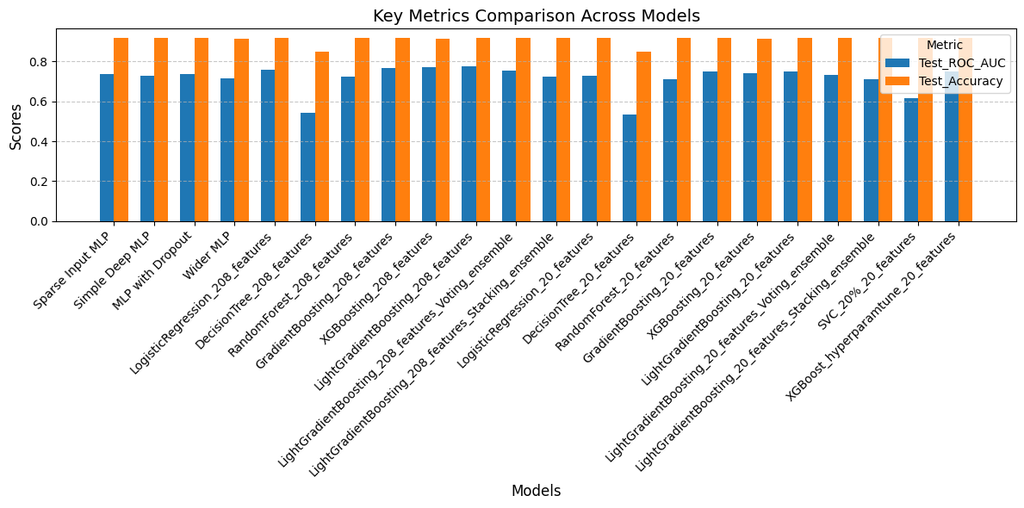

```python
import matplotlib.pyplot as plt
import numpy as np

mlp_metrics = experiment_logs_df[["Experiment_Name", "Test_ROC_AUC", "Test_Accuracy"]]
non_mlp_metrics = expLog[["Experiment_Name", "Test_ROC_AUC", "Test_Accuracy"]]

combined_df = pd.concat([mlp_metrics, non_mlp_metrics], ignore_index=True)

metrics_to_plot = ["Test_ROC_AUC", "Test_Accuracy"]


fig, ax = plt.subplots(figsize=(12, 6))


x = np.arange(len(combined_df["Experiment_Name"]))

width = 0.35

for i, metric in enumerate(metrics_to_plot):
    ax.bar(x + i * width, combined_df[metric], width, label=metric)

ax.set_xlabel("Models", fontsize=12)
ax.set_ylabel("Scores", fontsize=12)
ax.set_title("Key Metrics Comparison Across Models", fontsize=14)
ax.set_xticks(x + width / 2)
ax.set_xticklabels(combined_df["Experiment_Name"], rotation=45, ha="right")
ax.legend(title="Metric", fontsize=10)
ax.grid(axis="y", linestyle="--", alpha=0.7)

plt.tight_layout()
plt.show()
```

## **3.6 Upload to Kaggle**

```python
X_kaggle_test_tensor = torch.tensor(X_kaggle_test_reduced.values, dtype=torch.float32)
```

```python
%%time
# Generate predictions for Kaggle submission
test_class_scores = torch.argmax(loaded_model(X_kaggle_test_tensor), dim=1).numpy()
```

```
CPU times: user 86 ms, sys: 9.18 ms, total: 95.2 ms
Wall time: 51 ms
```

```python
# Submission dataframe
submit_df = datasets["application_test"][['SK_ID_CURR']]
submit_df['TARGET'] = test_class_scores

submit_df.head()
```

|  | SK_ID_CURR | TARGET |
| --- | --- | --- |
| 0 | 100001 | 0 |
| 1 | 100005 | 0 |
| 2 | 100013 | 0 |
| 3 | 100028 | 0 |
| 4 | 100038 | 0 |

```python
submit_df.to_csv("submission.csv",index=False)
```

```python
! kaggle competitions submit -c home-credit-default-risk -f submission.csv -m "baseline submission"
```

```
100% 428k/428k [00:01<00:00, 294kB/s]
Successfully submitted to Home Credit Default Risk
```